# Lecture_1 Hadoop

HDFS, MAPREDUCE, HIVE

### **HADOOP** - open source продукт

- несколько сервисов, составялющих "ядро" Hadoop
- Вся экосистема сервиса Hadoop
- Кластер под управлением Hadoop

Предпосылки появления

- потребность в распред. хранилищах
  - можно самому, но нужно разработать и прописать взаимодействие между всеми сложными узлами
- масштабирование вычислений
  - обработка данных не одной нодой -> горизонтальное масштабирование
- управление ресурсами
  - гибкая работа с ресурами - кому-то больше для важной задачи

[figure not shown]

**DWH** - классическая концепция для построения аналитических хранилищ, по сути строились на файлах csv формата - таблицы

- Логи, url page, json файлы тяжело запихнуть в DWH
- ELT - важен сам факт наличия данных, без трансформаций

**Cloudera** - поставка Hadoop как пазл - коробочное решение кластера

[figure not shown]

$$ {Hadoop} $$

[figure not shown]

- Доставщики источников данных
  - flume - бегает по источникам и складывает в HDFS
  - kafka - прогоняет через себя потоки данных: кто-то в нее пишет, кто-то читает. Универсальный переходник между системами
- Хранение данных
  - HDFS
- Ресурсы
  - YARN
- Обработка данных
  - MapReduce
  - Spark

#### Zookeeper

Хранение технической мета-информации: выжимки, что и где искать, конфиги.

Передача маленьких обьемов, но очень конкретно

[figure not shown]

файловая система

- можем добраться до ноды через адрес: foo.com:2181

[figure not shown]

Распределенная система

При разрыве связи между серверами и делении на группы -> определиться большинство серверов в группе и они будут работать, другие - меньшинство отключаться

#### HDFS (Hadoop Distributed File System)

Файловая система, предназначенная для хранения файлов больших размеров, поблочно распредел. между узлами вычислительного кластера

[figure not shown]

**NameNode** - основной элемент кластера

Файлы лежат в блоках, но есть инфа о блоках которые содержат целиковый файл

**NameNode** хранит информацию о файле и блоках в которых лежат данные этого файла, его содержимое

Клиент напрямую взаимодействует с **DataNodes**, а не через "узкое горлышко" - **NameNode**

Файл - это только запись в метаданных

Содержимое файла хранится в нескольких блоках одинакового размера

[figure not shown]

Размер блока ограничен по всему **HDFS**

Файла data.txt будет разрезан:

- 2 блока по 64 MB
- 1 блок по 32 MB

Хранение малых файлов (картинки) проблема, т.к про каждый файл заносится мета-информация и при одном и том же обьеме данных, получим большее число записей мета-информации в **NameNode**.

**NameNode** - одна и ее нужно хранить, и хранить ее оперативную память

[figure not shown]

Фактор репликации по умолчанию 3. При падении ноды, блок со здоровой ноды перетечет в утерянную

$$ Чтение $$

[figure not shown]

- 1 - 2: Клиент запрашивает у NameNode нахождение блоков с файлами
- 3 - 4, 5: Читаем блоки с DataNode

$$ Запись $$

[figure not shown]

- 1 - 2: Клиент запрашивает у NameNode возможности записи: права, куда писать
- 3 - 4, 5: Отправки пакетов с данными и проверка очереди, завершения записи
- 6 - 7: Сообщаем NameNode что запись окончена

High-Availability - у нас две NameNode: Active and StandBy

#### HDFS API

- libhdfs - C API
- FileSystem - Java API
- WebHDFS/HttpFS - REST API
- HDFS CLI

##### CLI Example

Главное понимать наличие 2-х файловых систем ФС

- Локальная
- HDFS

они между собой не взаимодействуют

```python
# путь в локальной ФС
! pwd
```

```
/data/home/ruslan.nagimov
```

```python
# содержимое корня локальной ФС
! ls /
```

```
bin	      etc	      lib	  opt	share  usr
boot	      hadoop	      lib64	  proc	snap   var
cgroups_test  home	      lost+found  root	srv    vmlinuz
data	      initrd.img      media	  run	sys    vmlinuz.old
dev	      initrd.img.old  mnt	  sbin	tmp
```

```python
# содержимое корня hdfs dfs
! hdfs dfs -ls /
```

```
Found 15 items
drwxrwxrwt   - yarn   hadoop          0 2022-11-03 19:55 /app-logs
drwxr-xr-x   - hdfs   hdfs            0 2022-01-06 17:15 /apps
drwxr-xr-x   - yarn   hadoop          0 2022-01-06 17:05 /ats
drwxr-xr-x   - hdfs   hdfs            0 2022-01-06 17:06 /atsv2
drwxr-xr-x   - hdfs   hdfs            0 2022-01-06 17:05 /hdp
drwxr-xr-x   - hdfs   hdfs            0 2022-06-08 15:42 /labs
drwxr-xr-x   - hdfs   hdfs            0 2022-01-06 18:47 /lectures
drwxr-xr-x   - mapred hdfs            0 2022-01-06 17:05 /mapred
drwxrwxrwx   - mapred hadoop          0 2022-01-06 17:05 /mr-history
drwxr-xr-x   - hdfs   hdfs            0 2022-01-06 17:05 /ranger
drwxrwxrwx   - spark  hadoop          0 2022-11-05 01:15 /spark2-history
drwxr-xr-x   - hdfs   hdfs            0 2022-08-17 21:15 /system
drwxrwxrwx   - hdfs   hdfs            0 2022-11-05 01:08 /tmp
drwxr-xr-x   - hdfs   hdfs            0 2022-10-26 20:47 /user
drwxr-xr-x   - hdfs   hdfs            0 2022-01-06 17:07 /warehouse
```

```python
#  создание папки на hdfs
! hdfs dfs -mkdir /tmp/hdfs-cli-example
```

```python
# понятно что она пустая
! hdfs dfs -ls /tmp/hdfs-cli-example
```

```python
# локальный файл
! echo "Hadoop is good" > example.txt

! cat example.txt
```

```
Hadoop is good
```

```python
# put -  загрузить, get - получить
             #  откуда - локальная ; куда - hdfs
! hdfs dfs -put example.txt /tmp/hdfs-cli-example
```

```python
! hdfs dfs -ls /tmp/hdfs-cli-example
```

```
Found 1 items
-rw-r--r--   3 ruslan.nagimov hdfs         15 2022-11-05 01:21 /tmp/hdfs-cli-example/example.txt
```

```python
! hdfs dfs -cat /tmp/hdfs-cli-example/example.txt
```

```
Hadoop is good
```

```python
! hdfs dfs -cp /tmp/hdfs-cli-example/example.txt /tmp/hdfs-cli-example/example2.txt
```

```python
! hdfs dfs -ls /tmp/hdfs-cli-example
```

```
Found 2 items
-rw-r--r--   3 ruslan.nagimov hdfs         15 2022-11-05 01:21 /tmp/hdfs-cli-example/example.txt
-rw-r--r--   3 ruslan.nagimov hdfs         15 2022-11-05 01:23 /tmp/hdfs-cli-example/example2.txt
```

```python
! hdfs dfs -get /tmp/hdfs-cli-example/example2.txt ./
```

```python
! ls
```

```
data	      example.txt  HW_3.ipynb	  lab02.json  Lectures.ipynb
data.csv      HW_1.ipynb   lab01.json	  lab031.csv  test.json
example2.txt  HW_2.ipynb   lab02_01.json  lab03.csv   Untitled.ipynb
```

```python
# оценка занимаемого места -du (disc usage) -> 15 байт ; 15 * 3 (фактор репликации) = 45
! hdfs dfs -du -h /tmp/hdfs-cli-example/example.txt
```

```
15  45  /tmp/hdfs-cli-example/example.txt
```

```python
# fsck - file system check
! hdfs fsck /tmp/hdfs-cli-example/example.txt -files -blocks -locations
```

```
Connecting to namenode via http://spark-master-1.newprolab.com:50070/fsck?ugi=ruslan.nagimov&files=1&blocks=1&locations=1&path=%2Ftmp%2Fhdfs-cli-example%2Fexample.txt
FSCK started by ruslan.nagimov (auth:SIMPLE) from /10.0.0.5 for path /tmp/hdfs-cli-example/example.txt at Sat Nov 05 01:28:15 MSK 2022
/tmp/hdfs-cli-example/example.txt 15 bytes, replicated: replication=3, 1 block(s):  OK
0. BP-316575162-10.0.0.17-1641477897677:blk_1080120999_6382984 len=15 Live_repl=3  [DatanodeInfoWithStorage[10.0.0.26:50010,DS-c5bdcef3-6eaa-4dcb-be71-a3091c095afe,DISK], DatanodeInfoWithStorage[10.0.0.17:50010,DS-9078edb9-084d-47bb-ba7e-13bd6df78029,DISK], DatanodeInfoWithStorage[10.0.0.3:50010,DS-…


Status: HEALTHY
 Number of data-nodes:	5
 Number of racks:		1
 Total dirs:			0
 Total symlinks:		0

Replicated Blocks:
 Total size:	15 B
 Total files:	1
 Total blocks (validated):	1 (avg. block size 15 B)
 Minimally replicated blocks:	1 (100.0 %)
 Over-replicated blocks:	0 (0.0 %)
 Under-replicated blocks:	0 (0.0 %)
 Mis-replicated blocks:		0 (0.0 %)
 Default replication factor:	3
 Average block replication:	3.0
 Missing blocks:		0
 Corrupt blocks:		0
 Missing replicas:		0 (0.0 %)

Erasure Coded Block Groups:
 Total size:	0 B
 Total files:	0
 Total block groups (validated):	0
 Minimally erasure-coded block groups:	0
 Over-erasure-coded block groups:	0
 Under-erasure-coded block groups:	0
 Unsatisfactory placement block groups:	0
 Average block group size:	0.0
 Missing block groups:		0
 Corrupt block groups:		0
 Missing internal blocks:	0
FSCK ended at Sat Nov 05 01:28:15 MSK 2022 in 4 milliseconds


The filesystem under path '/tmp/hdfs-cli-example/example.txt' is HEALTHY
```

```python
! rm example.txt example2.txt
```

```python
! hdfs dfs -rm -r /tmp/hdfs-cli-example
```

```
22/11/05 01:30:15 INFO fs.TrashPolicyDefault: Moved: 'hdfs://spark-master-1.newprolab.com:8020/tmp/hdfs-cli-example' to trash at: hdfs://spark-master-1.newprolab.com:8020/user/ruslan.nagimov/.Trash/Current/tmp/hdfs-cli-example
```

```python
# конфиги Hadoop
! ls /etc/hadoop/conf
```

```
capacity-scheduler.xml	    resource-types.xml
commons-logging.properties  secure
configuration.xsl	    slaves
container-executor.cfg	    ssl-client.xml
core-site.xml		    ssl-client.xml.example
embedded-yarn-ats-hbase     ssl-server.xml
hadoop-env.cmd		    ssl-server.xml.example
hadoop-env.sh		    taskcontroller.cfg
hadoop-metrics2.properties  task-log4j.properties
hadoop-policy.xml	    topology_mappings.data
hdfs-site.xml		    topology_script.py
health_check		    user_ec_policies.xml.template
log4j.properties	    workers
mapred-env.sh		    yarn-env.sh
mapred-queues.xml.template  yarnservice-log4j.properties
mapred-site.xml		    yarn-site.xml
```

#### YARN - Yet Another Resource Negotiator

Модуль, отвечающий за управление ресурсами кластеров и планирование заданий

Менеджеры ресурсов

- Kubernetes - микросервисы
- YARN - обработка данных

[figure not shown]

- Client запускает приложение на YARN
  - Отправка запросу Resource Manager
- NodeManager контролирует ресурсы одного сервера
  - На каждом сервере по одному NodeManager
- ResourceManager создает первый контейнер приложения - ApplicationMaster
- ApplicationMaster запрашивает доп. контейнеры у ResourceManager
- На картинке только 2 приложения, на одно приложение один ApplicationMaster

Разделение ресурсов происходит по очередям:

- Отд. очередь для долгих тяжелых задач
- Отд. очередь для мелких ad-hoc
- Отд. очередь для обучения моделей

##### Yarn Cli

```python
! yarn -h
```

```
Usage: yarn [OPTIONS] SUBCOMMAND [SUBCOMMAND OPTIONS]
 or    yarn [OPTIONS] CLASSNAME [CLASSNAME OPTIONS]
  where CLASSNAME is a user-provided Java class

  OPTIONS is none or any of:

--buildpaths                       attempt to add class files from build tree
--config dir                       Hadoop config directory
--daemon (start|status|stop)       operate on a daemon
--debug                            turn on shell script debug mode
--help                             usage information
--hostnames list[,of,host,names]   hosts to use in worker mode
--hosts filename                   list of hosts to use in worker mode
--loglevel level                   set the log4j level for this command
--workers                          turn on worker mode

  SUBCOMMAND is one of:


    Admin Commands:

daemonlog            get/set the log level for each daemon
node                 prints node report(s)
rmadmin              admin tools
scmadmin             SharedCacheManager admin tools

    Client Commands:

app|application      prints application(s) report/kill application/manage
                     long running application
applicationattempt   prints applicationattempt(s) report
classpath            prints the class path needed to get the hadoop jar and
                     the required libraries
cluster              prints cluster information
container            prints container(s) report
envvars              display computed Hadoop environment variables
jar <jar>            run a jar file
logs                 dump container logs
queue                prints queue information
schedulerconf        Updates scheduler configuration
timelinereader       run the timeline reader server
top                  view cluster information
version              print the version

    Daemon Commands:

nodemanager          run a nodemanager on each worker
proxyserver          run the web app proxy server
registrydns          run the registry DNS server
resourcemanager      run the ResourceManager
router               run the Router daemon
sharedcachemanager   run the SharedCacheManager daemon
timelineserver       run the timeline server

SUBCOMMAND may print help when invoked w/o parameters or with -h.
```

- ! yarn app -list -- список всех application
- ! yarn app -kill appid - убить application

#### MapReduce

Подход к организации распределеннх вчислений, предложеннй Google в работе “MapReduce: Simplified Data Processing on Large Clusters”

Главная идея: Вычисления можно представить как последовательность операций

- Map - трансформаций
- Shuffle - перераспределение данных
- Reduce - агрегаций

[figure not shown]

#### HIVE

- Позволяет выполнять запросы к слабоструктурированным данным
- Для запросов используется HiveQL
- Имеет свой metastore для хранения “данных о данных” (структур таблиц)

```
CREATE TABLE u_data_new ( userid INT,
movieid INT,
rating INT,
weekday INT)
ROW FORMAT DELIMITED
FIELDS TERMINATED BY '\t';
```

[figure not shown]

Пользователь кидает запрос к HiveServer через

- CLI
- JDBC / ODBC
- Web UI

HIVE Server смотрит в MetaStore

- Находит пути соответ. файлами, их форматы хранения

На основе формируется job, которая уходит выполняться на Hadoop

Партиции - разбиение данных на уровне файловой системы

Допустим, разбиение на года

```
CREATE TABLE page_view (
viewTime INT, userid BIGINT, page_url STRING
) PARTITIONED BY (dt STRING, country STRING)
STORED AS SEQUENCEFILE;
```

Посмотреть партиции

```
show create table имя_таблицы
```

Формат хранения

- STORED AS TEXTFILE
- STORED AS PARQUET - best for analytics
- STORED AS ORC - best for analytics

AVRO для потоковой записи

Часто встречающаяся ситуация

- есть внешняя таблица Hive
- туда были записаны данные
- данных не видно в запросах SQL

Поможет команда `MSCK REPAIR TABLE table_name`

##### Hive Cli

```python
! hive -e "select 1 as s"
```

[output not shown]

С Hive можно взаимодействовать через

- Beeline CLI
- HUE
- Библиотеки (JDBC, pyhive)

```
% bin/beeline
beeline> !connect jdbc:hive2://localhost:10000 user1 password1
0: jdbc:hive2://localhost:10000> show tables;
```

# Lecture_2

## Основные недостатки классического MapReduce

- Постоянное чтение/запись во внешнее хранилище
- Сложный API
- Ограниченное число источников/приемников данных
- MapReduce - это только вычислительный фреймворк
  - Есть данные, вычисления на фазе Map
  - Обмениваемся данными на стыке Map -> Reduce
  - Reduce снова обрабатывает данные

https://arxiv.org/pdf/1209.2191.pdf MapReduce is Good Enough? If All You Have is a Hammer, Throw Away Everything That’s Not a Nail!

Пример для Word Counter

Слишком обьемный для столь простой операции

- Mapper

[figure not shown]

- Reducer

[figure not shown]

## Apache Spark - это *быстрая* распределенная вычислительная платформа *общего назначения*

1. **Быстрая**
   - Кеширование рабочих данных в памяти
   - Ленивые вычисления
1. **Общего назначения**
   - Можно реализовать любые вычисления (батчевые, итеративные, интерактивные, в режиме реального времени)
   - Более общая модель программирования (узлы в графе вычислений могут быть не только map и reduce)
   - Высокоуровневый API (Scala, Java, Python, R)
     - Родной язык Scala, Python обр-ся через фасады и переписыается на Scala
   - Локальная установка
     - Скачать Java, Spark и можно играться локально

[figure not shown]

- Spark Core - основное ядро
- Spark SQL - привычный SQL синтаксис компилируется в нужный код
- Spark Streaming - потоковая обработка событий
- Mlib - пакет машинного обучения,
  - Распаралеливание алгоритмов специфичная штука
- GraphX - работа с графами
- Standalone Scheduler
  - SPARK самостоятелен, ему не нужна привязка к HADOOP
- YARN - менеджер ресурсов

[figure not shown]

Архитектура Apache Spark

[figure not shown]

- Клиент запрашивает ресурсы на том, чтобы запустить драйвер
  - Сначала запускается контейнер AppMaster, внутри которого запускается Spark Driver
- Spark Driver - обеспечивает функционировании и координацию параллельных вычислений для конкретной задачи
  - (5) SD возвращается в YARN и запрашивает необходимые ресурсы
- Запускается YARN NodeManager на вычислительных нодах
- Запускаются Executor Conatainer

Запуск локально

[figure not shown]

При отключении интернета, задача не завершится

Вычисление необходимых ресурсов, контейнеров строится на основании данных

## Запуск PySpark

```python
from IPython.display import IFrame, Image
```

```python
import os
import sys

# указываем интерпретатор Python
os.environ["PYSPARK_PYTHON"]='/opt/anaconda/envs/bd9/bin/python'
# указать папку распаковки Sparka
os.environ["SPARK_HOME"]='/usr/hdp/current/spark2-client'
# указываем хотелки по ресурсам - 3 экзекьютора, и память будет выделяться как настроено на кластере
os.environ["PYSPARK_SUBMIT_ARGS"]='--num-executors 3 pyspark-shell'


spark_home = os.environ.get('SPARK_HOME', None)

# указываем путь для работы jvm с Python
sys.path.insert(0, os.path.join(spark_home, 'python'))
sys.path.insert(0, os.path.join(spark_home, 'python/lib/py4j-0.10.7-src.zip'))
```

## SparkContext (sc) - это основной управляющий объект.

```python
from pyspark import SparkContext, SparkConf

conf = SparkConf()
conf.set("spark.app.name", "Sergey Grishaev Spark RDD app")

sc = SparkContext(conf=conf)
```

## Для получения всех установленных опций конфигурации можно использовать `sc.getConf()`

```python
sc.getConf().getAll()
```

```
[('spark.history.kerberos.keytab', 'none'),
 ('spark.eventLog.enabled', 'true'),
 ('spark.history.fs.cleaner.maxAge', '7d'),
 ('spark.history.ui.port', '18081'),
 ('spark.driver.extraLibraryPath',
  '/usr/hdp/current/hadoop-client/lib/native:/usr/hdp/current/hadoop-client/lib/native/Linux-amd64-64'),
 ('spark.repl.local.jars',
  'file:///data/home/ruslan.nagimov/.ivy2/jars/org.apache.spark_spark-sql-kafka-0-10_2.11-2.4.7.jar,file:///data/home/ruslan.nagimov/.ivy2/jars/graphframes_graphframes-0.8.1-spark2.4-s_2.11.jar,file:///data/home/ruslan.nagimov/.ivy2/jars/databricks_spark-sklearn-0.2.3.jar,file:///data/home/ruslan.na…
 ('spark.shuffle.io.serverThreads', '128'),
 ('spark.sql.streaming.streamingQueryListeners', ''),
 ('spark.executor.extraLibraryPath',
  '/usr/hdp/current/hadoop-client/lib/native:/usr/hdp/current/hadoop-client/lib/native/Linux-amd64-64'),
 ('spark.jars.repositories', 'https://repos.spark-packages.org/'),
 ('spark.shuffle.file.buffer', '1m'),
 ('spark.sql.hive.convertMetastoreOrc', 'true'),
 ('spark.yarn.dist.files', ''),
 ('spark.sql.autoBroadcastJoinThreshold', '26214400'),
 ('spark.history.fs.cleaner.interval', '1d'),
 ('spark.ui.filters',
  'org.apache.hadoop.yarn.server.webproxy.amfilter.AmIpFilter'),
 ('spark.eventLog.dir', 'hdfs:///spark2-history/'),
 ('spark.ui.proxyBase', '/proxy/application_1667306389915_1152'),
 ('spark.yarn.historyServer.address', 'spark-master-1.newprolab.com:18081'),
 ('spark.org.apache.hadoop.yarn.server.webproxy.amfilter.AmIpFilter.param.PROXY_URI_BASES',
  'http://spark-master-1.newprolab.com:8088/proxy/application_1667306389915_1152'),
 ('spark.executor.id', 'driver'),
 ('spark.sql.orc.impl', 'native'),
 ('spark.history.fs.logDirectory', 'hdfs:///spark2-history/'),
 ('spark.org.apache.hadoop.yarn.server.webproxy.amfilter.AmIpFilter.param.PROXY_HOSTS',
  'spark-master-1.newprolab.com'),
 ('spark.extraListeners', ''),
 ('spark.executorEnv.PYTHONPATH',
  '{{PWD}}/pyspark.zip<CPS>{{PWD}}/py4j-0.10.7-src.zip<CPS>{{PWD}}/org.apache.spark_spark-sql-kafka-0-10_2.11-2.4.7.jar<CPS>{{PWD}}/graphframes_graphframes-0.8.1-spark2.4-s_2.11.jar<CPS>{{PWD}}/databricks_spark-sklearn-0.2.3.jar<CPS>{{PWD}}/org.apache.kafka_kafka-clients-2.0.0.jar<CPS>{{PWD}}/org.sp…
 ('spark.sql.warehouse.dir', '/apps/spark/warehouse'),
 ('spark.history.store.path', '/var/lib/spark2/shs_db'),
 ('spark.port.maxRetries', '100'),
 ('spark.executor.instances', '3'),
 ('spark.driver.host', 'spark-master-5.newprolab.com'),
 ('spark.submit.pyFiles',
  '/data/home/ruslan.nagimov/.ivy2/jars/org.apache.spark_spark-sql-kafka-0-10_2.11-2.4.7.jar,/data/home/ruslan.nagimov/.ivy2/jars/graphframes_graphframes-0.8.1-spark2.4-s_2.11.jar,/data/home/ruslan.nagimov/.ivy2/jars/databricks_spark-sklearn-0.2.3.jar,/data/home/ruslan.nagimov/.ivy2/jars/org.apache.…
```

[output cut: 20 more lines]

```
 ('spark.history.kerberos.principal', 'none'),
 ('spark.jars.packages',
  'org.apache.spark:spark-sql-kafka-0-10_2.11:2.4.7,graphframes:graphframes:0.8.1-spark2.4-s_2.11,databricks:spark-sklearn:0.2.3'),
 ('spark.rdd.compress', 'True'),
 ('spark.sql.orc.filterPushdown', 'true'),
 ('spark.shuffle.io.backLog', '8192'),
 ('spark.yarn.dist.jars',
  'file:///data/home/ruslan.nagimov/.ivy2/jars/org.apache.spark_spark-sql-kafka-0-10_2.11-2.4.7.jar,file:///data/home/ruslan.nagimov/.ivy2/jars/graphframes_graphframes-0.8.1-spark2.4-s_2.11.jar,file:///data/home/ruslan.nagimov/.ivy2/jars/databricks_spark-sklearn-0.2.3.jar,file:///data/home/ruslan.na…
 ('spark.unsafe.sorter.spill.reader.buffer.size', '1m'),
 ('spark.yarn.isPython', 'true'),
 ('spark.shuffle.unsafe.file.output.buffer', '5m'),
 ('spark.executor.extraJavaOptions', '-XX:+UseNUMA'),
 ('spark.ui.showConsoleProgress', 'true'),
 ('spark.driver.port', '38097'),
 ('spark.sql.hive.metastore.version', '3.0')]
```

## Существует два способа создать RDD

- распределить коллекцию объектов с драйвера
- загрузить внешний датасет

Эта абстракция уровня DataFrame, но данные он в себе не хранит

## 1. Распределить коллекцию с драйвера

```python
import numpy as np

vocabulary = ("Apache", "Spark", "Hadoop")
numbers = np.random.randint(10, size=10000)
words = np.random.choice(vocabulary, size=10000)
collection = zip(numbers, words)
```

```python
rdd = sc.parallelize(collection)

rdd
```

```
ParallelCollectionRDD[0] at parallelize at PythonRDD.scala:195
```

rdd в себе данные не хранит, он хранит способ получения данных и способ восстановления данных - МетаИнформация

```python
rdd.count()
```

```
10000
```

```python
rdd.take(3)
```

```
[(0, 'Spark'), (7, 'Spark'), (8, 'Apache')]
```

```python
rdd.getNumPartitions()
```

```
3
```

3 Партиции - по сути это тоже блок данных и если запишем в HDFS, то будет 3 файла по умолчанию

Есть Экзьеюктор, в каждом Экзе может от одного до неск-ких процессорных ядер.

Task - минимальная единица работы, именно параллельной работы job'ы

Один Task обрабатывает одну Партицию. Один Task обрабатывается одним ядром на одном экзекьюторе

Если у нас 3 Партиции, то у нас будет 3 Taska -> когда делали .count()

## 2. Загрузить внешний датасет (датасет загружается из HDFS)

```python
# ! hdfs dfs -get /lectures/lecture01/data/log.txt ./
```

```python
! hdfs dfs -ls /lectures/lecture01/data
```

```
Found 3 items
-rw-r--r--   3 hdfs hdfs         28 2022-01-06 18:47 /lectures/lecture01/data/graph.tsv
-rw-r--r--   3 hdfs hdfs      19462 2022-01-06 18:47 /lectures/lecture01/data/ips.txt
drwxr-xr-x   - hdfs hdfs          0 2022-01-06 18:47 /lectures/lecture01/data/log.txt
```

```python
! hdfs dfs -ls /lectures/lecture01/data
```

```
Found 3 items
-rw-r--r--   3 hdfs hdfs         28 2022-01-06 18:47 /lectures/lecture01/data/graph.tsv
-rw-r--r--   3 hdfs hdfs      19462 2022-01-06 18:47 /lectures/lecture01/data/ips.txt
drwxr-xr-x   - hdfs hdfs          0 2022-01-06 18:47 /lectures/lecture01/data/log.txt
```

```python
! hdfs dfs -ls /lectures/lecture01/data/ips.txt
```

```
-rw-r--r--   3 hdfs hdfs      19462 2022-01-06 18:47 /lectures/lecture01/data/ips.txt
```

```python
# прочитали данные --- но на самом деле мы их не читаем, данные будут вычитываться при обращении к ним
rdd2 = sc.textFile('/lectures/lecture01/data/ips.txt')
```

```python
rdd2.take(3)
```

```
['192.168.0.1\tCHINA', '192.168.0.2\tCHINA', '192.168.0.3\tCHINA']
```

```python
rdd2.count()
```

```
1000
```

```python
rdd2.getNumPartitions()
```

```
2
```

2 Партиции не очень, т.к. выше мы запросили 3 экзекьютора

`os.environ["PYSPARK_SUBMIT_ARGS"]='--num-executors 3 pyspark-shell'`

То треть будет простаивать - 1/3, т.к заняты только 2

Увеличим число партиций и сделаем это с перекрытием, минимум 2 на один экзекьютор

```python
! hdfs dfs -ls /lectures/lecture01/data/ips.txt
```

```
-rw-r--r--   3 hdfs hdfs      19462 2022-01-06 18:47 /lectures/lecture01/data/ips.txt
```

```python
! hdfs dfs -ls -h
```

```
Found 4 items
drwx------   - ruslan.nagimov ruslan.nagimov          0 2022-11-06 00:40 .Trash
drwxr-xr-x   - ruslan.nagimov ruslan.nagimov          0 2022-11-06 02:42 .sparkStaging
drwxr-xr-x   - ruslan.nagimov ruslan.nagimov          0 2022-04-14 23:22 ips_3_repart.txt
drwxr-xr-x   - ruslan.nagimov ruslan.nagimov          0 2022-11-06 02:26 ips_6_repart.txt
```

```python
! hdfs dfs -rm -r ips_6_repart.txt
```

```
22/11/06 02:43:22 INFO fs.TrashPolicyDefault: Moved: 'hdfs://spark-master-1.newprolab.com:8020/user/ruslan.nagimov/ips_6_repart.txt' to trash at: hdfs://spark-master-1.newprolab.com:8020/user/ruslan.nagimov/.Trash/Current/user/ruslan.nagimov/ips_6_repart.txt1667691802185
```

```python
rdd2.repartition(6).saveAsTextFile('ips_6_repart.txt')
```

```python
rdd3 = sc.textFile('ips_6_repart.txt')
```

```python
rdd3.getNumPartitions()
```

```
6
```

## RDD API состоит из операции двух типов:

- action
- transformation

[figure not shown]

### Трансформация преобразовывает RDD в другой RDD и не приводит к вычислению графа

Накидываем логику на rdd, только после вызова action данные считаются/пойдут вычисления

```python
rdd = sc.parallelize(range(1000000))
rdd2 = rdd.filter(lambda x: x % 2)
```

```python
rdd2.getNumPartitions()
```

```
3
```

### Action заставляет Spark вычислить граф и вернуть результат либо на драйвер, либо во внешнее хранилище

```python
rdd2.count()
```

```
500000
```

```python
rdd2.take(10)
```

```
[1, 3, 5, 7, 9, 11, 13, 15, 17, 19]
```

сколько раз запускался фильтр, а сколько раз parallelize ?

2 и 2

Данные не хранятся в rdd2, вызываем методы и после идет граф вычислений

### Трансформации можно применять одну за другой, никаких вычислений не будет сделано, пока не будет вызван action

```python
rdd = sc.parallelize(range(1000000))
```

```python
rdd2 = rdd.filter(lambda x: x % 1000).filter(lambda x: x % 7)
rdd2
```

```
PythonRDD[21] at RDD at PythonRDD.scala:53
```

```python
rdd3 = rdd2.map(lambda x: x*2)
rdd3
```

```
PythonRDD[22] at RDD at PythonRDD.scala:53
```

```python
rdd3.collect()[:10]
```

```
[2, 4, 6, 8, 10, 12, 16, 18, 20, 22]
```

### `take()` пытается минимизировать число обращений к партициям, поэтому может возвращать смещенные результаты

```python
rdd3.take(10)
```

```
[2, 4, 6, 8, 10, 12, 16, 18, 20, 22]
```

с `collect()` стоит быть аккуратней, т.к он все тянет на драйвер

### Будьте аккуратны с `collect()`, потому что он загружает все данные из RDD на драйвер. Это может легко привести к Out of Memory exception

```python
rdd.collect()[:20]
```

```
[0, 1, 2, 3, 4, 5, 6, 7, 8, 9, 10, 11, 12, 13, 14, 15, 16, 17, 18, 19]
```

### Если нужно получить небольшое число записей на драйвер и, при этом, сохранить распределение, то лучше сделать выборку

```python
rdd.takeSample(withReplacement=False, num=20, seed=5757)
```

```
[347399,
 536788,
 94124,
 169558,
 729189,
 836541,
 973939,
 512558,
 171385,
 123303,
 364321,
 587839,
 139749,
 532891,
 757568,
 969298,
 544812,
 690521,
 175014,
 895109]
```

## Познакомимся с данными. Будем работать с двумя таблицами

[figure not shown]

### Примеры трансформаций

```python
rdd = sc.textFile("/lectures/lecture01/data/ips.txt")
```

```python
rdd.getNumPartitions()
```

```
2
```

```python
rdd.take(3)
```

```
['192.168.0.1\tCHINA', '192.168.0.2\tCHINA', '192.168.0.3\tCHINA']
```

```python
ips = rdd.map(lambda x: x.split('\t'))
```

```python
ips.take(3)
```

```
[['192.168.0.1', 'CHINA'], ['192.168.0.2', 'CHINA'], ['192.168.0.3', 'CHINA']]
```

```python
ips_filtered = ips.filter(lambda x: x[1] != 'CHINA')
```

```python
ips_filtered.take(3)
```

```
[['192.168.0.201', 'RUSSIA'],
 ['192.168.0.202', 'RUSSIA'],
 ['192.168.0.203', 'RUSSIA']]
```

```python
raw_logs = sc.textFile('/lectures/lecture01/data/log.txt')
```

```python
raw_logs.getNumPartitions()
```

```
4
```

Почему в одной 2, в другой 4 Партиции

ips.txt - текстовый файл, и Спарк выставляется жесткие условия - 2 Партиции

log - папка, в которой 4 файла и выделяется по одной партиции на каждый файл

```python
! hdfs dfs -ls /lectures/lecture01/data/log.txt
```

```
Found 5 items
-rw-r--r--   3 hdfs hdfs          0 2022-01-06 18:47 /lectures/lecture01/data/log.txt/_SUCCESS
-rw-r--r--   3 hdfs hdfs   12650786 2022-01-06 18:47 /lectures/lecture01/data/log.txt/part-00000
-rw-r--r--   3 hdfs hdfs   12644978 2022-01-06 18:47 /lectures/lecture01/data/log.txt/part-00001
-rw-r--r--   3 hdfs hdfs   12646744 2022-01-06 18:47 /lectures/lecture01/data/log.txt/part-00002
-rw-r--r--   3 hdfs hdfs   12676672 2022-01-06 18:47 /lectures/lecture01/data/log.txt/part-00003
```

```python
! hdfs dfs -ls /lectures/lecture01/data/ips.txt
```

```
-rw-r--r--   3 hdfs hdfs      19462 2022-01-06 18:47 /lectures/lecture01/data/ips.txt
```

```python
raw_logs.take(3)
```

```
['192.168.0.10\tERROR\tWhen production fails in dipsair, whom you gonna call?',
 '192.168.0.39\tINFO\tJust an info message passing by',
 '192.168.0.35\tINFO\tJust an info message passing by']
```

```python
logs = raw_logs.map(lambda x: x.split('\t'))
```

```python
logs.take(3)
```

```
[['192.168.0.10',
  'ERROR',
  'When production fails in dipsair, whom you gonna call?'],
 ['192.168.0.39', 'INFO', 'Just an info message passing by'],
 ['192.168.0.35', 'INFO', 'Just an info message passing by']]
```

```python
logs.flatMap(lambda x: x[2].split()).take(10)
```

```
['When',
 'production',
 'fails',
 'in',
 'dipsair,',
 'whom',
 'you',
 'gonna',
 'call?',
 'Just']
```

```python
words = logs.flatMap(lambda x: x[2].split())
words.take(3)
```

```
['When', 'production', 'fails']
```

```python
words.groupBy(lambda x: x).count()
```

```
19
```

Уникальных слов - 19

## Зачем нужны отдельные трансформации и отдельные action?

[figure not shown]

### Последовательность трансформаций определяет граф вычислений (DAG - direct acyclic graph). В нем есть партиции и зависимости между партициями. Таким образом Spark имеет всю необходимую информацию для вычилсения графа в любой точке и возможных оптимизаций

[figure not shown]

### Трансформации бывают *узкими*

[figure not shown]

### И *широкими*

[figure not shown]

### Широкие трансформации разделяют джоб на стейджи. Между стейджами происходит shuffle данных, которого надо избегать. Кстати почему?

- При дисбалансе ключей может все лечь
- Shuffle перекидывает целые данные файлов

## Summary:

```
- Каждое действие (action) инициирует новое задание (job)
- Spark анализирует граф RDD и строит план выполнения
- План выполнения может включать несколько этапов (stages)
- Каждый этап состоит из набора задач (tasks) - полняется один и тот же код на разных кусочках данных
```

**Jobs -> Stages -> Task (1 Task - 1 Partition**

```python
rdd = sc.textFile("/lectures/lecture01/data/ips.txt")

ips = rdd.map(lambda x: x.split("\t"))
ips_filtered = ips.filter(lambda x: x[1] != "CHINA")

ips_filtered.take(5)
```

```
[['192.168.0.201', 'RUSSIA'],
 ['192.168.0.202', 'RUSSIA'],
 ['192.168.0.203', 'RUSSIA'],
 ['192.168.0.204', 'RUSSIA'],
 ['192.168.0.205', 'RUSSIA']]
```

```python
raw_logs = sc.textFile("/lectures/lecture01/data/log.txt")

logs = raw_logs.map(lambda x: x.split("\t"))
words = logs.flatMap(lambda x: x[2].split())

words.groupBy(lambda x: x).count()
```

```
19
```

## Персистентность и кэширование

### RDD вычисляются лениво, когда вызывается action. Часто мы хотим вызвать несколько actions для одного и тоге же RDD. Если мы просто сделаем это, то граф будет полностью перевычисляться каждый раз.

```python
ips.count()
```

```
1000
```

```python
ips.top(10)
```

```
[['192.168.3.99', 'USA'],
 ['192.168.3.98', 'USA'],
 ['192.168.3.97', 'USA'],
 ['192.168.3.96', 'USA'],
 ['192.168.3.95', 'USA'],
 ['192.168.3.94', 'USA'],
 ['192.168.3.93', 'USA'],
 ['192.168.3.92', 'USA'],
 ['192.168.3.91', 'USA'],
 ['192.168.3.90', 'USA']]
```

### Чтобы этого избежать, мы можем закэшировать RDD в памяти. Кэширование произойдет при вызове первого action.

```python
ips_cached = ips.cache()
```

```python
ips_cached.count()
```

```
1000
```

```python
# операция из кеша, поэтому быстрее
ips_cached.top(3)
```

```
[['192.168.3.99', 'USA'], ['192.168.3.98', 'USA'], ['192.168.3.97', 'USA']]
```

Кешировать эффективно то, что часто будет использоваться.. Есть готовая подвыборка, которую будем использовать неск-ко раз

### `cache()` сохраняет RDD в памяти. Для большего контроля можно использовать `persist(storage_level)`:

- MEMORY_ONLY - только в оперативной памяти (ОП), сохранится в ОП в экзекьютора, подефолту выделяется 50% доступной памяти
- MEMORY_AND_DISK - в памяти, пока не закончится. Данные кешируются партициями, добавляются в память полными партициями
- DISK_ONLY - временная папка на локальном диске
- MEMORY_ONLY_2 - как и первый вариант, но создается еще копия кеша (2 реплики на разных нодах)
- MEMORY_AND_DISK_2 - как и второй вариант

## Удаление данных из кэша

- Автоматическое (LRU cache)

```python
ips_cached.unpersist()
```

```
PythonRDD[55] at RDD at PythonRDD.scala:53
```

### Обработка отказов

- Промежуточные результаты не сохраняются в HDFS
- RDD по-умолчанию не реплицируются
- Для восстановления потерянных данных используется информация о происхождении
- Spark восстанавливает потерянные фрагменты RDD, заново вычисляя их путем применения трансформаций

## PairRDD (ключ-значение)

### PairRDD - это RDD для работы с парами ключ-значение. Spark предполагает, что PairRDD содержит в себе объекты, состящие ровно из двух элементов! PairRDD предоставляют методы группировки, аггрегации и объединения (join) двух RDD

### Пусть есть задача подсчитать распределение кодов ERROR и WARNING в лог-файле

```python
raw_logs.take(5)
```

```
['192.168.0.10\tERROR\tWhen production fails in dipsair, whom you gonna call?',
 '192.168.0.39\tINFO\tJust an info message passing by',
 '192.168.0.35\tINFO\tJust an info message passing by',
 '192.168.0.19\tINFO\tJust an info message passing by',
 '192.168.0.23\tERROR\tWhen production fails in dipsair, whom you gonna call?']
```

```python
(raw_logs.filter(lambda x: "INFO" not in x)
         .map(lambda x: (x.split("\t")[1], 1))\
         .groupByKey()
         .collect())
```

```
[('ERROR', <pyspark.resultiterable.ResultIterable at 0x7f6ff03667f0>),
 ('WARNING', <pyspark.resultiterable.ResultIterable at 0x7f6ff0366978>)]
```

```python
(raw_logs.filter(lambda x: "INFO" not in x)
         .map(lambda x: (x.split("\t")[1], 1))\
         .groupByKey()
         .map(lambda x: (x[0], len(x[1])))
         .collect())
```

```
[('WARNING', 250004), ('ERROR', 49948)]
```

По сути реализовали **group by** и **count**

### Или немного проще

```python
(raw_logs.filter(lambda x: "INFO" not in x)
         .map(lambda x: (x.split("\t")[1], 1))
         .countByKey()
         .items())
```

```
dict_items([('ERROR', 49948), ('WARNING', 250004)])
```

### Стоит заметить, что `groupByKey()` предполагает перемещение всех записей с одним ключом на один экзекьютор. В случае очень скошенных распределений это может привести к падению экзекьютора с OOM. Поэтому всегда при группировках стоит подумать об использовании `reduceByKey()`.

```python
(raw_logs.filter(lambda x: "INFO" not in x)
         .map(lambda x: (x.split("\t")[1], 1))\
         .reduceByKey(lambda x, y: x + y)
         .collect())
```

```
[('WARNING', 250004), ('ERROR', 49948)]
```

`reduceByKey` - сделает промежуточную агрегацию внутри одной партиции перед reducer

## Join

### Два PairRDD можно объединить по ключу

### Поддерживаются inner join, left outer join, right outer join и full outer join

```python
logs.take(5)
```

```
[['192.168.0.10',
  'ERROR',
  'When production fails in dipsair, whom you gonna call?'],
 ['192.168.0.39', 'INFO', 'Just an info message passing by'],
 ['192.168.0.35', 'INFO', 'Just an info message passing by'],
 ['192.168.0.19', 'INFO', 'Just an info message passing by'],
 ['192.168.0.23',
  'ERROR',
  'When production fails in dipsair, whom you gonna call?']]
```

```python
ips.take(5)
```

```
[['192.168.0.1', 'CHINA'],
 ['192.168.0.2', 'CHINA'],
 ['192.168.0.3', 'CHINA'],
 ['192.168.0.4', 'CHINA'],
 ['192.168.0.5', 'CHINA']]
```

```python
%%time
logs.join(ips).take(5)
```

```
CPU times: user 12 ms, sys: 7.8 ms, total: 19.8 ms
Wall time: 1.83 s
```

```
[('192.168.0.64', ('WARNING', 'CHINA')),
 ('192.168.0.64', ('INFO', 'CHINA')),
 ('192.168.0.64', ('INFO', 'CHINA')),
 ('192.168.0.64', ('INFO', 'CHINA')),
 ('192.168.0.64', ('INFO', 'CHINA'))]
```

Потерялся столбец из logs.. RDD работает с парами - (ключ: значение)

### Не стоит забывать, что Spark предполагает, что PairRDD состоит ровно! из двух элементов, поэтому все остальные элементы просто отбрасываются!

```python
def split_logs(line):
    split = line.split("\t")
    return split[0], split[1:]
```

```python
logs_cached = raw_logs.map(split_logs).cache()
```

```python
logs_cached.take(5)
```

```
[('192.168.0.10',
  ['ERROR', 'When production fails in dipsair, whom you gonna call?']),
 ('192.168.0.39', ['INFO', 'Just an info message passing by']),
 ('192.168.0.35', ['INFO', 'Just an info message passing by']),
 ('192.168.0.19', ['INFO', 'Just an info message passing by']),
 ('192.168.0.23',
  ['ERROR', 'When production fails in dipsair, whom you gonna call?'])]
```

```python
%%time
logs_cached.join(ips).take(5)
```

```
CPU times: user 13 ms, sys: 4.31 ms, total: 17.3 ms
Wall time: 6.48 s
```

```
[('192.168.0.64', (['WARNING', 'Something bad could happen'], 'CHINA')),
 ('192.168.0.64', (['INFO', 'Just an info message passing by'], 'CHINA')),
 ('192.168.0.64', (['INFO', 'Just an info message passing by'], 'CHINA')),
 ('192.168.0.64', (['INFO', 'Just an info message passing by'], 'CHINA')),
 ('192.168.0.64', (['INFO', 'Just an info message passing by'], 'CHINA'))]
```

## Управление параллелизмом.

### Вспомним, что атомарным уровнем параллелизма в Spark является партиция. Об этом всегда стоит помнить, когда есть проблемы с производительностью приложения

```python
logs.getNumPartitions()
```

```
4
```

### Метод `repartition()` может быть использован для изменения числа партиций.

```python
logs = logs.repartition(100000)
```

```python
logs.getNumPartitions()
```

```
100000
```

### `repartition()` всегда приводит к равномерному перераспределению данных, что ведет к shuffle. Если Вы уменьшаете число партиций, то стоит использовать `coalesce()`, который может избежать shuffle

```python
logs = logs.coalesce(10)
```

```python
logs.getNumPartitions()
```

```
10
```

```python
logs = logs.coalesce(2)
```

```python
logs.getNumPartitions()
```

```
2
```

### Узнать дефолтный уровень параллелизма можно из конфига. По-умолчанию, при работе с YARN, использукется общее число ядер, выделенных этому SparkContext на всех экзекьюторах, либо 2. Что больше.

```python
print(sc.getConf().get("spark.default.parallelism"))
```

```
None
```

```python
sc.parallelize(range(100000)).getNumPartitions()
```

```
3
```

## Broadcast

### Broadcast-объект - это неизменяемая переменная, которая разделяется между всеми экзекьюторами

### Дистрибуция broadcast-объекта производится быстро и эффективно p2p-протоколом

### Реализуем map-side join с помощью broadcast-объекта

- Есть огромная таблица
- Есть справочник
  - делаем из него dict()
  - бродкастим dict()
    - передается на все работающие экзекьюторы

-- Джойны таблиц сильно разных размеров

```python
ips_local = dict(ips.collect())
```

```python
import itertools

dict(itertools.islice(ips_local.items(), 3))
```

```
{'192.168.0.1': 'CHINA', '192.168.0.2': 'CHINA', '192.168.0.3': 'CHINA'}
```

```python
ips_local['192.168.0.10']
```

```
'CHINA'
```

```python
ips_broadcasted = sc.broadcast(ips_local)
```

Теперь этот обьект будет сразу доступен на каждом Экзекьюторе

```python
ips_broadcasted.value['192.168.0.10']
```

```
'CHINA'
```

```python
logs_cached.take(5)
```

```
[('192.168.0.10',
  ['ERROR', 'When production fails in dipsair, whom you gonna call?']),
 ('192.168.0.39', ['INFO', 'Just an info message passing by']),
 ('192.168.0.35', ['INFO', 'Just an info message passing by']),
 ('192.168.0.19', ['INFO', 'Just an info message passing by']),
 ('192.168.0.23',
  ['ERROR', 'When production fails in dipsair, whom you gonna call?'])]
```

```python
def resolve_ip(row):
    return ips_broadcasted.value[row[0]], row[1:] ## row[0] is the IP address
```

```python
%%time
logs_cached.map(resolve_ip).take(10)
```

```
CPU times: user 4.23 ms, sys: 1.1 ms, total: 5.33 ms
Wall time: 44.7 ms
```

```
[('CHINA',
  (['ERROR', 'When production fails in dipsair, whom you gonna call?'],)),
 ('CHINA', (['INFO', 'Just an info message passing by'],)),
 ('CHINA', (['INFO', 'Just an info message passing by'],)),
 ('CHINA', (['INFO', 'Just an info message passing by'],)),
 ('CHINA',
  (['ERROR', 'When production fails in dipsair, whom you gonna call?'],)),
 ('CHINA',
  (['ERROR', 'When production fails in dipsair, whom you gonna call?'],)),
 ('CHINA', (['INFO', 'Just an info message passing by'],)),
 ('CHINA', (['WARNING', 'Something bad could happen'],)),
 ('CHINA', (['INFO', 'Just an info message passing by'],)),
 ('CHINA', (['INFO', 'Just an info message passing by'],))]
```

Меньше ресурсов, т.к маленькую таблицу раскидали на все Экзекьюторы, а большая таблица считается Партициями

## Не забудьте погасить SparkContext!

```python
sc.stop()
```

# Lecture_3

```python
import os
import sys
os.environ["PYSPARK_PYTHON"]='/opt/anaconda/envs/bd9/bin/python'
os.environ["SPARK_HOME"]='/usr/hdp/current/spark2-client'

# 3 Экзекьютора
### На каждый по 3 гига памяти и 2 гига на драйвер
os.environ["PYSPARK_SUBMIT_ARGS"]='--num-executors 3 --executor-memory 3g --driver-memory 2g pyspark-shell'

spark_home = os.environ.get('SPARK_HOME', None)

sys.path.insert(0, os.path.join(spark_home, 'python'))
sys.path.insert(0, os.path.join(spark_home, 'python/lib/py4j-0.10.7-src.zip'))
```

```python
# инициализация Spark сессии

from pyspark import SparkConf
from pyspark.sql import SparkSession

conf = SparkConf()
conf.set("spark.app.name", "app")

spark = SparkSession.builder.config(conf=conf).appName("Spark app").getOrCreate()
```

```python
spark
```

**SparkSession - in-memory**

**SparkContext**

[Spark UI](http://spark-master-5.newprolab.com:4051)

**Version**

`v2.4.7`

**Master**

`yarn`

**AppName**

`Spark app`

Spark Session: - обертка над контекстами

```
- Spark Context
- SQL Context
- Hive Context
- Streaming Context
```

```python
# получение Spark контекста
sc = spark.sparkContext
sc
```

**SparkContext**

[Spark UI](http://spark-master-5.newprolab.com:4051)

**Version**

`v2.4.7`

**Master**

`yarn`

**AppName**

`Spark app`

```python
%pylab inline
```

## Как создать DataFrame?

### Прочитать из внешнего источника

```python
# спец метод
spark.read
```

```
<pyspark.sql.readwriter.DataFrameReader at 0x7fe042ff7a58>
```

### pipeline загрузки

```
spark.read\
     .format(...)\
     .option(key, value)\
     .option(key, value)\
     .load(path)
```

```python
df = spark.read\
          .format("csv")\
          .option("sep", "|")\
          .load("/lectures/lecture02/data/ml-100k/u.user")
```

```python
df
```

```
DataFrame[_c0: string, _c1: string, _c2: string, _c3: string, _c4: string]
```

```python
df.show(3)
```

```
+---+---+---+----------+-----+
|_c0|_c1|_c2|       _c3|  _c4|
+---+---+---+----------+-----+
|  1| 24|  M|technician|85711|
|  2| 53|  F|     other|94043|
|  3| 23|  M|    writer|32067|
+---+---+---+----------+-----+
only showing top 3 rows
```

```python
df.take(3)
```

```
[Row(_c0='1', _c1='24', _c2='M', _c3='technician', _c4='85711'),
 Row(_c0='2', _c1='53', _c2='F', _c3='other', _c4='94043'),
 Row(_c0='3', _c1='23', _c2='M', _c3='writer', _c4='32067')]
```

### Schema!

```python
from pyspark.sql.types import StructType, StructField, IntegerType, StringType
```

```python
# описываем данные
schema = StructType(fields=[
    StructField("user_id", IntegerType()),
    StructField("age", IntegerType()),
    StructField("gender", StringType()),
    StructField("occupation", StringType()),
    StructField("zip", IntegerType())
])
```

```python
df = spark.read\
            .schema(schema)\
          .format("csv")\
          .option("sep", "|")\
          .load("/lectures/lecture02/data/ml-100k/u.user")
```

```python
df
```

```
DataFrame[user_id: int, age: int, gender: string, occupation: string, zip: int]
```

```python
df.printSchema()
```

```
root
 |-- user_id: integer (nullable = true)
 |-- age: integer (nullable = true)
 |-- gender: string (nullable = true)
 |-- occupation: string (nullable = true)
 |-- zip: integer (nullable = true)
```

Почему иерархия через root

- закладка под json

```python
df.show(5)
```

```
+-------+---+------+----------+-----+
|user_id|age|gender|occupation|  zip|
+-------+---+------+----------+-----+
|      1| 24|     M|technician|85711|
|      2| 53|     F|     other|94043|
|      3| 23|     M|    writer|32067|
|      4| 24|     M|technician|43537|
|      5| 33|     F|     other|15213|
+-------+---+------+----------+-----+
only showing top 5 rows
```

```python
df.summary().show()
```

```
+-------+-----------------+-----------------+------+-------------+------------------+
|summary|          user_id|              age|gender|   occupation|               zip|
+-------+-----------------+-----------------+------+-------------+------------------+
|  count|              925|              925|   925|          925|               925|
|   mean|470.2908108108108|34.06054054054054|  null|         null| 50868.78810810811|
| stddev|272.1030147185632|12.25807489536592|  null|         null|30891.373254138176|
|    min|                1|                7|     F|administrator|                 0|
|    25%|              236|               25|  null|         null|             21227|
|    50%|              469|               31|  null|         null|             53711|
|    75%|              705|               43|  null|         null|             78741|
|    max|              943|               73|     M|       writer|             99835|
+-------+-----------------+-----------------+------+-------------+------------------+
```

### Таким образом более приближенный к реальности pipeline выглядит как

```
spark.read\
     .schema(schema)\
     .format(...)\
     .option(key, value)\
     .option(key, value)\
     .load(path)
```

### Есть так же удобные wrapper'ы

```python
df = spark.read.csv("/lectures/lecture02/data/ml-100k/u.user", schema=schema, sep="|")
```

```python
df
```

```
DataFrame[user_id: int, age: int, gender: string, occupation: string, zip: int]
```

```python
df.show(5)
```

```
+-------+---+------+----------+-----+
|user_id|age|gender|occupation|  zip|
+-------+---+------+----------+-----+
|      1| 24|     M|technician|85711|
|      2| 53|     F|     other|94043|
|      3| 23|     M|    writer|32067|
|      4| 24|     M|technician|43537|
|      5| 33|     F|     other|15213|
+-------+---+------+----------+-----+
only showing top 5 rows
```

```python
df
```

```
DataFrame[user_id: int, age: int, gender: string, occupation: string, zip: int]
```

```python
df.show(5)
```

```
+-------+---+------+----------+-----+
|user_id|age|gender|occupation|  zip|
+-------+---+------+----------+-----+
|      1| 24|     M|technician|85711|
|      2| 53|     F|     other|94043|
|      3| 23|     M|    writer|32067|
|      4| 24|     M|technician|43537|
|      5| 33|     F|     other|15213|
+-------+---+------+----------+-----+
only showing top 5 rows
```

### Много источников данных с унифицированным API!

- CSV
- JSON
- Hive
- HBase
- Cassandra
- MySQL
- PostgreSQL
- Parquet
- ORC
- Kafka
- ElasticSearch
- Amazon S3
- ...и еще больше через custom connectors

### Создадим DataFrame из RDD, pandas.DataFrame или из list

```python
rdd = sc.textFile("/lectures/lecture02/data/ml-100k/u.user").map(lambda x: x.split("|"))
```

```python
rdd.take(5)
```

```
[['1', '24', 'M', 'technician', '85711'],
 ['2', '53', 'F', 'other', '94043'],
 ['3', '23', 'M', 'writer', '32067'],
 ['4', '24', 'M', 'technician', '43537'],
 ['5', '33', 'F', 'other', '15213']]
```

```python
df = spark.createDataFrame(rdd)
```

```python
df
```

```
DataFrame[_1: string, _2: string, _3: string, _4: string, _5: string]
```

```python
df = spark.createDataFrame(rdd, schema=schema)
```

```python
df
```

```
DataFrame[user_id: int, age: int, gender: string, occupation: string, zip: int]
```

```python
df.show(3)
```

[output not shown]

[output cut: 123 more lines]

[output not shown]

Не нравится поле - не соответствие типов данных

Scala строго типизированный язык

### Может быть с неправильными типами можно справится путем игнорирования верификации schema???

```python
df = spark.createDataFrame(rdd, schema=schema, verifySchema=False)
df
```

```
DataFrame[user_id: int, age: int, gender: string, occupation: string, zip: int]
```

```python
df.show(5)
```

```
+-------+----+------+----------+----+
|user_id| age|gender|occupation| zip|
+-------+----+------+----------+----+
|   null|null|     M|technician|null|
|   null|null|     F|     other|null|
|   null|null|     M|    writer|null|
|   null|null|     M|technician|null|
|   null|null|     F|     other|null|
+-------+----+------+----------+----+
only showing top 5 rows
```

### Не выходит требуется конвертировать в правильные типы

```python
rdd = rdd.map(lambda x: (int(x[0]), int(x[1]), x[2], x[3], int(x[4])))
rdd
```

```
PythonRDD[65] at RDD at PythonRDD.scala:53
```

```python
df = spark.createDataFrame(rdd, schema=schema)
```

```python
df.show(5)
```

```
+-------+---+------+----------+-----+
|user_id|age|gender|occupation|  zip|
+-------+---+------+----------+-----+
|      1| 24|     M|technician|85711|
|      2| 53|     F|     other|94043|
|      3| 23|     M|    writer|32067|
|      4| 24|     M|technician|43537|
|      5| 33|     F|     other|15213|
+-------+---+------+----------+-----+
only showing top 5 rows
```

## Поработаем с искусственным access логом

```python
!hdfs dfs -tail /lectures/lecture02/data/logsM.txt
```

```python
from pyspark.sql.types import LongType

log_schema = StructType(fields=[
    StructField("ip", StringType()),
    StructField("timestamp", LongType()),
    StructField("url", StringType()),
    StructField("size", IntegerType()),
    StructField("code", IntegerType()),
    StructField("ua", StringType())
])
```

```python
log = spark.read.csv("/lectures/lecture02/data/logsM.txt", sep="\t", schema=log_schema).cache()
```

Закешировали, чтобы не тратить время на прогрузку каждый раз

```python
log
```

```
DataFrame[ip: string, timestamp: bigint, url: string, size: int, code: int, ua: string]
```

```python
log.rdd.getNumPartitions()
```

```
1
```

```python
log = log.repartition(6)
log.rdd.getNumPartitions()
```

```
6
```

```python
# воспользуемся доп. выводом
log.show(3, vertical=True, truncate=False)
```

```
-RECORD 0-----------------------------------------------------------------------------------------------------------------------------
 ip        | 222.131.187.37
 timestamp | 20140112193801
 url       | http://news.mail.ru/7703130
 size      | 903
 code      | 504
 ua        | Chrome/5.0 (compatible; MSIE 9.0; Windows NT 6.1; Win64; x64; Trident/5.0; .NET CLR 3.5.30729;)
-RECORD 1-----------------------------------------------------------------------------------------------------------------------------
 ip        | 168.146.187.80
 timestamp | 20140309090040
 url       | http://news.rambler.ru/3165291
 size      | 773
 code      | 456
 ua        | Opera/5.0 (compatible; MSIE 9.0; Windows NT 6.1; Win64; x64; Trident/5.0; .NET CLR 2.0.50727; SLCC2; .NET CLR 3.5.30729)
-RECORD 2-----------------------------------------------------------------------------------------------------------------------------
 ip        | 33.49.147.163
 timestamp | 20140410014351
 url       | http://newsru.com/9238321
 size      | 1088
 code      | 409
 ua        | Chrome/5.0 compatible; MSIE 9.0; Windows NT 7.0; Trident/5.0; .NET CLR 2.2.50767;)
only showing top 3 rows
```

## Projections и filters

Projection - это подмножество колонок - конкретные столбцы, а не select *

Filter - это подмножество строк

```python
log.schema.fieldNames()
```

```
['ip', 'timestamp', 'url', 'size', 'code', 'ua']
```

```python
log.select(["ip", "timestamp", "url"])
```

```
DataFrame[ip: string, timestamp: bigint, url: string]
```

```python
log.select(*log.schema.fieldNames()[:3]).show(5)
```

```
+---------------+--------------+--------------------+
|             ip|     timestamp|                 url|
+---------------+--------------+--------------------+
|  75.208.40.166|20140210083843|http://news.rambl...|
| 168.255.93.197|20140112215951|http://news.rambl...|
|135.124.143.193|20140313110843|http://news.mail....|
|  33.49.147.163|20140420043616|http://lenta.ru/4...|
|   49.105.15.79|20140118143400|http://lenta.ru/2...|
+---------------+--------------+--------------------+
only showing top 5 rows
```

Стараемся не тащить лишние столбцы, строки - сразу все отрезаем

```python
log.select("ip", "code").show(5)
```

```
+---------------+----+
|             ip|code|
+---------------+----+
|   49.105.15.79| 101|
|135.124.143.193| 303|
|135.124.143.193| 303|
|135.124.143.193| 303|
| 231.119.88.198| 511|
+---------------+----+
only showing top 5 rows
```

```python
log.select(log.ip, log.code).show(5)
```

```
+---------------+----+
|             ip|code|
+---------------+----+
|   49.105.15.79| 101|
|135.124.143.193| 303|
|135.124.143.193| 303|
|135.124.143.193| 303|
| 231.119.88.198| 511|
+---------------+----+
only showing top 5 rows
```

```python
# обьект - можно передавать и строки, и столбцы
log.ip
```

```
Column<b'ip'>
```

## Aliasing

```python
log.select(log.ip,
           log.code.alias("response")).show(5)
```

```
+---------------+--------+
|             ip|response|
+---------------+--------+
|   49.105.15.79|     101|
|135.124.143.193|     303|
|135.124.143.193|     303|
|135.124.143.193|     303|
| 231.119.88.198|     511|
+---------------+--------+
only showing top 5 rows
```

```python
import pyspark.sql.functions as f
```

```python
## микс, но так лучше не делать а придерживаться одного стиля
log.select("ip",
           f.col("code")).show(5)
```

```
+---------------+----+
|             ip|code|
+---------------+----+
|   49.105.15.79| 101|
|135.124.143.193| 303|
|135.124.143.193| 303|
|135.124.143.193| 303|
| 231.119.88.198| 511|
+---------------+----+
only showing top 5 rows
```

## Good ol' Pandas

```python
log[["ip", "code"]].show(5)
```

```
+---------------+----+
|             ip|code|
+---------------+----+
|   49.105.15.79| 101|
|135.124.143.193| 303|
|135.124.143.193| 303|
|135.124.143.193| 303|
| 231.119.88.198| 511|
+---------------+----+
only showing top 5 rows
```

```python
log[[log.ip, log.code.alias("response")]].show(5)
```

```
+---------------+--------+
|             ip|response|
+---------------+--------+
|   49.105.15.79|     101|
|135.124.143.193|     303|
|135.124.143.193|     303|
|135.124.143.193|     303|
| 231.119.88.198|     511|
+---------------+--------+
only showing top 5 rows
```

## Filtering

```python
log.where("code = 200").show(3)
```

```
+--------------+--------------+--------------------+----+----+--------------------+
|            ip|     timestamp|                 url|size|code|                  ua|
+--------------+--------------+--------------------+----+----+--------------------+
|197.72.248.141|20140404122749|http://newsru.com...| 884| 200|Opera/5.0 (compat...|
| 75.208.40.166|20140120192527|http://lenta.ru/8...| 722| 200|Safari/5.0 (compa...|
|197.72.248.141|20140403130026|http://news.yande...| 856| 200|Opera/5.0 (compat...|
+--------------+--------------+--------------------+----+----+--------------------+
only showing top 3 rows
```

```python
log.filter(log.code == 200).show(3, truncate=False)
```

```
+--------------+--------------+-----------------------------+----+----+----------------------------------------------------------------------------------------------------------+
|ip            |timestamp     |url                          |size|code|ua                                                                                                        |
+--------------+--------------+-----------------------------+----+----+----------------------------------------------------------------------------------------------------------+
|197.72.248.141|20140404122749|http://newsru.com/7833710    |884 |200 |Opera/5.0 (compatible; MSIE 9.0; Windows NT 6.1; WOW64; Trident/5.0; chromeframe/12.0.742.112)            |
|75.208.40.166 |20140120192527|http://lenta.ru/8240100      |722 |200 |Safari/5.0 (compatible; MSIE 9.0; Windows NT 8.0; WOW64; Trident/5.0; .NET CLR 2.7.40781; .NET4.0E; en-SG)|
|197.72.248.141|20140403130026|http://news.yandex.ru/2010781|856 |200 |Opera/5.0 (compatible; MSIE 9.0; Windows NT 8.0; WOW64; Trident/5.0; .NET CLR 2.7.40781; .NET4.0E; en-SG) |
+--------------+--------------+-----------------------------+----+----+----------------------------------------------------------------------------------------------------------+
only showing top 3 rows
```

```python
log.filter("code == 200 AND url LIKE '%rambler%'").show(3, truncate=False, vertical=True)
```

```
-RECORD 0-----------------------------------------------------------------------------------------------------
 ip        | 75.208.40.166
 timestamp | 20140310132240
 url       | http://news.rambler.ru/9308492
 size      | 1107
 code      | 200
 ua        | Opera/5.0 (compatible; MSIE 9.0; Windows NT 6.1; Win64; x64; Trident/5.0; .NET CLR 3.5.30729;)
-RECORD 1-----------------------------------------------------------------------------------------------------
 ip        | 33.49.147.163
 timestamp | 20140131095711
 url       | http://news.rambler.ru/3828463
 size      | 1908
 code      | 200
 ua        | Safari/5.0 (Windows; U; MSIE 9.0; Windows NT 8.1; Trident/5.0; .NET4.0E; en-AU)
-RECORD 2-----------------------------------------------------------------------------------------------------
 ip        | 33.49.147.163
 timestamp | 20140106045941
 url       | http://news.rambler.ru/1817681
 size      | 671
 code      | 200
 ua        | Firefox/5.0 (compatible; MSIE 9.0; Windows NT 6.1; Win64; x64; Trident/5.0; .NET CLR 3.5.30729;)
only showing top 3 rows
```

```python
log.filter((log.code.isin([200, 404])) & (log.url.like("%rambler%"))).show(3)
```

```
+--------------+--------------+--------------------+----+----+--------------------+
|            ip|     timestamp|                 url|size|code|                  ua|
+--------------+--------------+--------------------+----+----+--------------------+
|197.72.248.141|20140222074905|http://news.rambl...|1264| 200|Chrome/5.0 compat...|
| 75.208.40.166|20140202002148|http://news.rambl...|1338| 404|Opera/5.0 (compat...|
|197.72.248.141|20140210221913|http://news.rambl...|1654| 404|Safari/5.0 (Windo...|
+--------------+--------------+--------------------+----+----+--------------------+
only showing top 3 rows
```

## Good ol' Pandas

```python
log[(log.code == 200) & (log.url.like("%rambler%"))].show(3)
```

```
+-------------+--------------+--------------------+----+----+--------------------+
|           ip|     timestamp|                 url|size|code|                  ua|
+-------------+--------------+--------------------+----+----+--------------------+
|75.208.40.166|20140310132240|http://news.rambl...|1107| 200|Opera/5.0 (compat...|
|33.49.147.163|20140131095711|http://news.rambl...|1908| 200|Safari/5.0 (Windo...|
|33.49.147.163|20140106045941|http://news.rambl...| 671| 200|Firefox/5.0 (comp...|
+-------------+--------------+--------------------+----+----+--------------------+
only showing top 3 rows
```

## Все вместе

```python
log[(log.code == 200) & (log.url.like("%rambler%"))][["ip", "code"]].show(5)
```

```
+---------------+----+
|             ip|code|
+---------------+----+
|247.182.249.253| 200|
|  75.208.40.166| 200|
|   25.62.10.220| 200|
|  33.49.147.163| 200|
| 197.72.248.141| 200|
+---------------+----+
only showing top 5 rows
```

## Что же насчет SQL?! Он тут как тут)

```python
query = """
SELECT ip, code FROM log_table
WHERE code == 200 AND url LIKE '%rambler%'
"""
```

```python
spark.sql(query).show(5)
```

[output not shown]

[output cut: 62 more lines]

[output not shown]

### Надо зарегистрировать свой DataFrame как table

- по сути глобального ничего не произойдет, просто таблица станет доступной в запросе SQL

```python
log.createOrReplaceTempView("log_table")
```

```python
spark.sql(query).show(5)
```

```
+---------------+----+
|             ip|code|
+---------------+----+
|247.182.249.253| 200|
|  75.208.40.166| 200|
|   25.62.10.220| 200|
|  33.49.147.163| 200|
| 197.72.248.141| 200|
+---------------+----+
only showing top 5 rows
```

## Как Spark будет выполнять запрос?

Catalyst оптимизатор запроса SPARK

- Запрос парсится
  - Общая информация по запросу
- Передается в Catalyst

```python
spark.sql(query).explain(5)
```

```
== Parsed Logical Plan ==
'Project ['ip, 'code]
+- 'Filter (('code = 200) && 'url LIKE %rambler%)
   +- 'UnresolvedRelation `log_table`

== Analyzed Logical Plan ==
ip: string, code: int
Project [ip#5661, code#5665]
+- Filter ((code#5665 = 200) && url#5663 LIKE %rambler%)
   +- SubqueryAlias `log_table`
      +- Repartition 6, true
         +- Relation[ip#5661,timestamp#5662L,url#5663,size#5664,code#5665,ua#5666] csv

== Optimized Logical Plan ==
Repartition 6, true
+- Project [ip#5661, code#5665]
   +- Filter (((isnotnull(code#5665) && isnotnull(url#5663)) && (code#5665 = 200)) && Contains(url#5663, rambler))
      +- InMemoryRelation [ip#5661, timestamp#5662L, url#5663, size#5664, code#5665, ua#5666], StorageLevel(disk, memory, deserialized, 1 replicas)
            +- *(1) FileScan csv [ip#5661,timestamp#5662L,url#5663,size#5664,code#5665,ua#5666] Batched: false, Format: CSV, Location: InMemoryFileIndex[hdfs://spark-master-1.newprolab.com:8020/lectures/lecture02/data/logsM.txt], PartitionFilters: [], PushedFilters: [], ReadSchema: struct<ip:string,…

== Physical Plan ==
Exchange RoundRobinPartitioning(6)
+- *(1) Project [ip#5661, code#5665]
   +- *(1) Filter (((isnotnull(code#5665) && isnotnull(url#5663)) && (code#5665 = 200)) && Contains(url#5663, rambler))
      +- InMemoryTableScan [code#5665, ip#5661, url#5663], [isnotnull(code#5665), isnotnull(url#5663), (code#5665 = 200), Contains(url#5663, rambler)]
            +- InMemoryRelation [ip#5661, timestamp#5662L, url#5663, size#5664, code#5665, ua#5666], StorageLevel(disk, memory, deserialized, 1 replicas)
                  +- *(1) FileScan csv [ip#5661,timestamp#5662L,url#5663,size#5664,code#5665,ua#5666] Batched: false, Format: CSV, Location: InMemoryFileIndex[hdfs://spark-master-1.newprolab.com:8020/lectures/lecture02/data/logsM.txt], PartitionFilters: [], PushedFilters: [], ReadSchema: struct<ip:s…
```

`spark.sql(query).explain(True)`

== Parsed Logical Plan == ...

== Analyzed Logical Plan == ...

== Optimized Logical Plan == ...

== Physical Plan == ...

Catalyst

- библиотека для представления и манипуляции деревьями
- набор библиотек для выполнения реляционных запросов (выражения, планы и т.д.)
- набор правил применяемых на разных фазах обработки запросов

[figure not shown]

Основной тип данных Catalyst - дерево

```
Literal(value: Int)
Attr(name: String)
Add(left: TreeNode, right: TreeNode)
```

[figure not shown]

### Разбор плана запроса

```
SELECT country,
count(country) as messages
FROM table1 JOIN table2
WHERE table1.ip = table2.ip
AND table1.code != "INFO"
GROUP BY country
```

[figure not shown]

**== Parsed Logical Plan ==**

[figure not shown]

**== Analyzed Logical Plan ==**

[figure not shown]

**== Optimized Logical Plan ==**

- Произошел Filter Push Down

[figure not shown]

**== Physical Plan ==**

- Формат parquet (имеет под собой статистику) позволяет прокидывать условия внутрь, т.е мы будем вычитывать не все

[figure not shown]

## Встроенные функции есть 3 типов

- mapping (one to one)
- generating (one to many)
- aggregating (many to one)

```python
log.select("ua", f.length("ua")).show(5)
```

```
+--------------------+----------+
|                  ua|length(ua)|
+--------------------+----------+
|Safari/5.0 (compa...|        95|
|Safari/5.0 (compa...|        95|
|Safari/5.0 (compa...|        95|
|Safari/5.0 (compa...|        95|
|Safari/5.0 (compa...|        95|
+--------------------+----------+
only showing top 5 rows
```

```python
log.select("ua", f.length("ua").alias("length")).show(5)
```

```
+--------------------+------+
|                  ua|length|
+--------------------+------+
|Safari/5.0 (compa...|    95|
|Safari/5.0 (compa...|    95|
|Safari/5.0 (compa...|    95|
|Safari/5.0 (compa...|    95|
|Safari/5.0 (compa...|    95|
+--------------------+------+
only showing top 5 rows
```

```python
log.select(f.concat("url", "?utm_medium=email")).show(5)
```

[output not shown]

[output cut: 64 more lines]

[output not shown]

**`concat` необходим `Column` как аргумент. `lit` создает новую `Column` из literal**

```python
# теперь он поймет что сейчас оба объекта типа column
log.select(f.concat("url", f.lit("?utm_medium=email")).alias("newurl")).show(5, False)
```

```
+-----------------------------------------------+
|newurl                                         |
+-----------------------------------------------+
|http://news.yandex.ru/4761980?utm_medium=email |
|http://newsru.com/9387648?utm_medium=email     |
|http://news.rambler.ru/2396720?utm_medium=email|
|http://news.rambler.ru/7522218?utm_medium=email|
|http://newsru.com/5728483?utm_medium=email     |
+-----------------------------------------------+
only showing top 5 rows
```

## Explosions!

```python
log.select("ua", f.split("ua", " ").alias("word_list")).show(2, False, True)
```

```
-RECORD 0---------------------------------------------------------------------------------------------------------------
 ua        | Safari/5.0 (compatible; MSIE 9.0; Windows NT 6.1; WOW64; Trident/5.0; chromeframe/12.0.742.112)
 word_list | [Safari/5.0, (compatible;, MSIE, 9.0;, Windows, NT, 6.1;, WOW64;, Trident/5.0;, chromeframe/12.0.742.112)]
-RECORD 1---------------------------------------------------------------------------------------------------------------
 ua        | Safari/5.0 (compatible; MSIE 9.0; Windows NT 6.1; WOW64; Trident/5.0; chromeframe/12.0.742.112)
 word_list | [Safari/5.0, (compatible;, MSIE, 9.0;, Windows, NT, 6.1;, WOW64;, Trident/5.0;, chromeframe/12.0.742.112)]
only showing top 2 rows
```

**Можно выбирать отдельные элементы из list!**

```python
log.select("ua", f.split("ua", " ").alias("word_list"))\
   .select(f.col("word_list")[0], f.col("word_list")[1])\
   .show(5)
```

```
+------------+------------+
|word_list[0]|word_list[1]|
+------------+------------+
|  Safari/5.0|(compatible;|
|  Safari/5.0|(compatible;|
|  Safari/5.0|(compatible;|
|  Safari/5.0|(compatible;|
|  Safari/5.0|(compatible;|
+------------+------------+
only showing top 5 rows
```

```python
# explode развернет весь массив слов в столбец
log.select("ua", f.split("ua", " ").alias("word_list"))\
    .select(f.explode("word_list").alias("word"))\
    .show(5)
```

```
+------------+
|        word|
+------------+
|  Safari/5.0|
|(compatible;|
|        MSIE|
|        9.0;|
|     Windows|
+------------+
only showing top 5 rows
```

```python
log.select("ua", f.split("ua", " ").alias("word_list"))\
   .select(f.explode("word_list").alias("word"))\
   .groupby("word").count()\
   .orderBy("count", ascending=False)\
   .show(5)
```

```
+------------+-----+
|        word|count|
+------------+-----+
|        MSIE|10092|
|        9.0;|10092|
|          NT|10092|
|     Windows|10092|
|Trident/5.0;| 9121|
+------------+-----+
only showing top 5 rows
```

## Joins

```python
! hdfs dfs -tail /lectures/lecture02/data/ipDataM.txt
```

```
96.67	Khanty–Mansi
197.72.248.141	Chechnya
33.49.147.163	Nizhny Novgorod Oblast
56.167.169.126	Voronezh Oblast
3.183.113.77	Astrakhan Oblast
56.167.169.126	Tver Oblast
56.167.169.126	Kabardino-Balkaria
56.167.169.126	Nenets Autonomous Okrug
33.49.147.163	Omsk Oblast
14.8.59.211	Khabarovsk Krai
75.208.40.166	Sakha
135.124.143.193	Samara Oblast
75.208.40.166	Novosibirsk Oblast
75.208.40.166	Amur Oblast
75.208.40.166	Karelia
75.208.40.166	Saint Petersburg
181.217.177.35	Samara Oblast
33.49.147.163	Irkutsk Oblast
56.167.169.126	Lipetsk Oblast
181.217.177.35	Kalmykia
168.255.93.197	Volgograd Oblast
168.255.93.197	Oryol Oblast
168.255.93.197	Kurgan Oblast
168.146.187.80	Primorsky Krai
49.105.15.79	North Ossetia–Alania
197.72.248.141	Stavropol Krai
14.8.59.211	Kemerovo Oblast
49.203.96.67	Ulyanovsk Oblast
222.131.187.37	Yamalo-Nenets
197.72.248.141	Zabaykalsky Krai
222.131.187.37	Kaluga Oblast
3.183.113.77	Saratov Oblast
168.255.93.197	Astrakhan Oblast
75.208.40.166	Novgorod Oblast
135.124.143.193	Tambov Oblast
```

```python
ip_schema = StructType(fields=[
    StructField("ip", StringType()),
    StructField("region", StringType())
])
```

```python
ips = spark.read.csv("/lectures/lecture02/data/ipDataM.txt", schema=ip_schema, sep="\t").cache()
```

```python
ips.show(5)
```

```
+--------------+------------------+
|            ip|            region|
+--------------+------------------+
|  49.105.15.79|              Komi|
|110.91.102.196|Chelyabinsk Oblast|
|56.167.169.126|  Saint Petersburg|
| 75.208.40.166|  Ulyanovsk Oblast|
|168.255.93.197|    Irkutsk Oblast|
+--------------+------------------+
only showing top 5 rows
```

### Алгоритмы join

- Соединение вложенным циклом
- Соединение хэшированием
- Соединение сортировкой и слиянием (sort-merge)

**Соединение вложенным циклом**

```
for row1 in table1:
    for row2 in table2:
        if join_condition(row1, row2) is True:
            yield row1 + row2
```

- Любое условие соединения
- O(n * m) Очень медленный!

**Соединение хэшированием**

- Должна быть одна отн-но маленькая таблица
  - Относительно малая == на каждом экзекьюторе должен поместиться dict этой таблицы

```
hashtable = {}

# запихиваем малую таблицу на все экзекьюторы
for row in small_table:
    hashtable[row.join_key] = row

for row in large_table:
    if row.join_key in hashtable:
        yield row + hashtable[row.join_key]
```

- O (n + m)
- Только equijoin
- Хэш-таблица использует память

Sort-merge join по дефолту

```
i, j = 0, 0
while(i < len(sorted1) and j < len(sorted2)):
    if sorted1[i].join_key < sorted2[j].join_key:
        i += 1
    elif sorted1[i].join_key == sorted2[j].join_key:
        yield sorted1[i] + sorted2[j]
        i += 1
        j += 1
    else:
        j += 1
```

- O(n *log(n) + m* log(m))
- Может использоваться для огромных таблиц
- Разные условия слияния
- Ключи должны быть сортируемы

Типы физических планов

- Broadcast join
- Shuffle hash join
- Sort-merge join
- Broadcast nested loop join

**Sort-merge join**

- spark.sql.join.preferSortMergeJoin is True
- Алгоритм по-умолчанию
- Ключи должны быть сортируемы

```
# число партиций после джойна
spark.sql.shuffle.partitions = 200
```

**Broadcast join**

    ```
    spark.conf.set("spark.sql.autoBroadcastJoinThreshold", 10485760)
    ```

- Заброадкастить маленький dataframe

- Сделать map-side join

```python
spark.conf.set("spark.sql.autoBroadcastJoinThreshold", "10000000")
```

```python
log.rdd.getNumPartitions()
```

```
6
```

```python
ips.rdd.getNumPartitions()
```

```
1
```

```python
log_with_regions = log.join(ips, on="ip", how="outer")
```

```python
log_with_regions
```

```
DataFrame[ip: string, timestamp: bigint, url: string, size: int, code: int, ua: string, region: string]
```

```python
log_with_regions.show(15)
```

```
+--------------+--------------+--------------------+----+----+--------------------+--------------------+
|            ip|     timestamp|                 url|size|code|                  ua|              region|
+--------------+--------------+--------------------+----+----+--------------------+--------------------+
|154.64.206.187|          null|                null|null|null|                null|         Tver Oblast|
|154.64.206.187|          null|                null|null|null|                null| Karachay–Cherkessia|
|154.64.206.187|          null|                null|null|null|                null|             Karelia|
|154.64.206.187|          null|                null|null|null|                null|         Omsk Oblast|
|154.64.206.187|          null|                null|null|null|                null|    Leningrad Oblast|
|154.64.206.187|          null|                null|null|null|                null|       Moscow Oblast|
|154.64.206.187|          null|                null|null|null|                null|      Magadan Oblast|
|154.64.206.187|          null|                null|null|null|                null|            Buryatia|
|154.64.206.187|          null|                null|null|null|                null|        Penza Oblast|
|154.64.206.187|          null|                null|null|null|                null|                Komi|
|154.64.206.187|          null|                null|null|null|                null|Nizhny Novgorod O...|
|154.64.206.187|          null|                null|null|null|                null|         Tula Oblast|
|154.64.206.187|          null|                null|null|null|                null|            Kalmykia|
|  3.183.113.77|20140124012924|http://news.mail....|1251| 407|Safari/5.0 (Windo...|            Chukotka|
|  3.183.113.77|20140124012924|http://news.mail....|1251| 407|Safari/5.0 (Windo...|      Ivanovo Oblast|
+--------------+--------------+--------------------+----+----+--------------------+--------------------+
only showing top 15 rows
```

```python
log_with_regions.rdd.getNumPartitions()
```

```
200
```

```python
spark.conf.get("spark.sql.shuffle.partitions")
```

```
'200'
```

Нам не нужно столько партиций, т.к всего 3 Экзекьютора

```python
log_with_regions = log_with_regions.coalesce(6).cache()
log_with_regions
```

```
DataFrame[ip: string, timestamp: bigint, url: string, size: int, code: int, ua: string, region: string]
```

## Query planner использует SortMergeJoin по дефолту

```python
log_with_regions.explain(extended=True)
```

```
== Parsed Logical Plan ==
Repartition 6, false
+- Project [coalesce(ip#5661, ip#6746) AS ip#6789, timestamp#5662L, url#5663, size#5664, code#5665, ua#5666, region#6747]
   +- Join FullOuter, (ip#5661 = ip#6746)
      :- Repartition 6, true
      :  +- Relation[ip#5661,timestamp#5662L,url#5663,size#5664,code#5665,ua#5666] csv
      +- Relation[ip#6746,region#6747] csv

== Analyzed Logical Plan ==
ip: string, timestamp: bigint, url: string, size: int, code: int, ua: string, region: string
Repartition 6, false
+- Project [coalesce(ip#5661, ip#6746) AS ip#6789, timestamp#5662L, url#5663, size#5664, code#5665, ua#5666, region#6747]
   +- Join FullOuter, (ip#5661 = ip#6746)
      :- Repartition 6, true
      :  +- Relation[ip#5661,timestamp#5662L,url#5663,size#5664,code#5665,ua#5666] csv
      +- Relation[ip#6746,region#6747] csv

== Optimized Logical Plan ==
InMemoryRelation [ip#6789, timestamp#5662L, url#5663, size#5664, code#5665, ua#5666, region#6747], StorageLevel(disk, memory, deserialized, 1 replicas)
   +- Coalesce 6
      +- *(3) Project [coalesce(ip#5661, ip#6746) AS ip#6789, timestamp#5662L, url#5663, size#5664, code#5665, ua#5666, region#6747]
         +- SortMergeJoin [ip#5661], [ip#6746], FullOuter
            :- *(1) Sort [ip#5661 ASC NULLS FIRST], false, 0
            :  +- Exchange hashpartitioning(ip#5661, 200)
            :     +- Exchange RoundRobinPartitioning(6)
            :        +- InMemoryTableScan [ip#5661, timestamp#5662L, url#5663, size#5664, code#5665, ua#5666]
            :              +- InMemoryRelation [ip#5661, timestamp#5662L, url#5663, size#5664, code#5665, ua#5666], StorageLevel(disk, memory, deserialized, 1 replicas)
            :                    +- *(1) FileScan csv [ip#5661,timestamp#5662L,url#5663,size#5664,code#5665,ua#5666] Batched: false, Format: CSV, Location: InMemoryFileIndex[hdfs://spark-master-1.newprolab.com:8020/lectures/lecture02/data/logsM.txt], PartitionFilters: [], PushedFilters: [], ReadSche…
            +- *(2) Sort [ip#6746 ASC NULLS FIRST], false, 0
               +- Exchange hashpartitioning(ip#6746, 200)
                  +- InMemoryTableScan [ip#6746, region#6747]
                        +- InMemoryRelation [ip#6746, region#6747], StorageLevel(disk, memory, deserialized, 1 replicas)
                              +- *(1) FileScan csv [ip#6746,region#6747] Batched: false, Format: CSV, Location: InMemoryFileIndex[hdfs://spark-master-1.newprolab.com:8020/lectures/lecture02/data/ipDataM.txt], PartitionFilters: [], PushedFilters: [], ReadSchema: struct<ip:string,region:string>

== Physical Plan ==
InMemoryTableScan [ip#6789, timestamp#5662L, url#5663, size#5664, code#5665, ua#5666, region#6747]
   +- InMemoryRelation [ip#6789, timestamp#5662L, url#5663, size#5664, code#5665, ua#5666, region#6747], StorageLevel(disk, memory, deserialized, 1 replicas)
         +- Coalesce 6
            +- *(3) Project [coalesce(ip#5661, ip#6746) AS ip#6789, timestamp#5662L, url#5663, size#5664, code#5665, ua#5666, region#6747]
               +- SortMergeJoin [ip#5661], [ip#6746], FullOuter
                  :- *(1) Sort [ip#5661 ASC NULLS FIRST], false, 0
                  :  +- Exchange hashpartitioning(ip#5661, 200)
                  :     +- Exchange RoundRobinPartitioning(6)
                  :        +- InMemoryTableScan [ip#5661, timestamp#5662L, url#5663, size#5664, code#5665, ua#5666]
                  :              +- InMemoryRelation [ip#5661, timestamp#5662L, url#5663, size#5664, code#5665, ua#5666], StorageLevel(disk, memory, deserialized, 1 replicas)
                  :                    +- *(1) FileScan csv [ip#5661,timestamp#5662L,url#5663,size#5664,code#5665,ua#5666] Batched: false, Format: CSV, Location: InMemoryFileIndex[hdfs://spark-master-1.newprolab.com:8020/lectures/lecture02/data/logsM.txt], PartitionFilters: [], PushedFilters: [], Re…
                  +- *(2) Sort [ip#6746 ASC NULLS FIRST], false, 0
                     +- Exchange hashpartitioning(ip#6746, 200)
                        +- InMemoryTableScan [ip#6746, region#6747]
                              +- InMemoryRelation [ip#6746, region#6747], StorageLevel(disk, memory, deserialized, 1 replicas)
                                    +- *(1) FileScan csv [ip#6746,region#6747] Batched: false, Format: CSV, Location: InMemoryFileIndex[hdfs://spark-master-1.newprolab.com:8020/lectures/lecture02/data/ipDataM.txt], PartitionFilters: [], PushedFilters: [], ReadSchema: struct<ip:string,region:string>
```

## Broadcast hint

```python
log_with_regions = log.join(f.broadcast(ips), on="ip", how="inner")
```

```python
log_with_regions.explain()
```

```
== Physical Plan ==
*(3) Project [ip#5661, timestamp#5662L, url#5663, size#5664, code#5665, ua#5666, region#6747]
+- *(3) BroadcastHashJoin [ip#5661], [ip#6746], Inner, BuildRight
   :- Exchange RoundRobinPartitioning(6)
   :  +- *(1) Filter isnotnull(ip#5661)
   :     +- InMemoryTableScan [ip#5661, timestamp#5662L, url#5663, size#5664, code#5665, ua#5666], [isnotnull(ip#5661)]
   :           +- InMemoryRelation [ip#5661, timestamp#5662L, url#5663, size#5664, code#5665, ua#5666], StorageLevel(disk, memory, deserialized, 1 replicas)
   :                 +- *(1) FileScan csv [ip#5661,timestamp#5662L,url#5663,size#5664,code#5665,ua#5666] Batched: false, Format: CSV, Location: InMemoryFileIndex[hdfs://spark-master-1.newprolab.com:8020/lectures/lecture02/data/logsM.txt], PartitionFilters: [], PushedFilters: [], ReadSchema: struct<i…
   +- BroadcastExchange HashedRelationBroadcastMode(List(input[0, string, false]))
      +- *(2) Filter isnotnull(ip#6746)
         +- InMemoryTableScan [ip#6746, region#6747], [isnotnull(ip#6746)]
               +- InMemoryRelation [ip#6746, region#6747], StorageLevel(disk, memory, deserialized, 1 replicas)
                     +- *(1) FileScan csv [ip#6746,region#6747] Batched: false, Format: CSV, Location: InMemoryFileIndex[hdfs://spark-master-1.newprolab.com:8020/lectures/lecture02/data/ipDataM.txt], PartitionFilters: [], PushedFilters: [], ReadSchema: struct<ip:string,region:string>
```

## Или можно использовать метод `hint()`

```python
log_with_regions = log.join(ips.hint("broadcast"), on="ip", how="inner").cache()
```

```python
log_with_regions.explain(True)
```

```
== Parsed Logical Plan ==
'Join UsingJoin(Inner,Buffer(ip))
:- Repartition 6, true
:  +- Relation[ip#5661,timestamp#5662L,url#5663,size#5664,code#5665,ua#5666] csv
+- ResolvedHint (broadcast)
   +- Relation[ip#6746,region#6747] csv

== Analyzed Logical Plan ==
ip: string, timestamp: bigint, url: string, size: int, code: int, ua: string, region: string
Project [ip#5661, timestamp#5662L, url#5663, size#5664, code#5665, ua#5666, region#6747]
+- Join Inner, (ip#5661 = ip#6746)
   :- Repartition 6, true
   :  +- Relation[ip#5661,timestamp#5662L,url#5663,size#5664,code#5665,ua#5666] csv
   +- ResolvedHint (broadcast)
      +- Relation[ip#6746,region#6747] csv

== Optimized Logical Plan ==
InMemoryRelation [ip#5661, timestamp#5662L, url#5663, size#5664, code#5665, ua#5666, region#6747], StorageLevel(disk, memory, deserialized, 1 replicas)
   +- *(3) Project [ip#5661, timestamp#5662L, url#5663, size#5664, code#5665, ua#5666, region#6747]
      +- *(3) BroadcastHashJoin [ip#5661], [ip#6746], Inner, BuildRight
         :- Exchange RoundRobinPartitioning(6)
         :  +- *(1) Filter isnotnull(ip#5661)
         :     +- InMemoryTableScan [ip#5661, timestamp#5662L, url#5663, size#5664, code#5665, ua#5666], [isnotnull(ip#5661)]
         :           +- InMemoryRelation [ip#5661, timestamp#5662L, url#5663, size#5664, code#5665, ua#5666], StorageLevel(disk, memory, deserialized, 1 replicas)
         :                 +- *(1) FileScan csv [ip#5661,timestamp#5662L,url#5663,size#5664,code#5665,ua#5666] Batched: false, Format: CSV, Location: InMemoryFileIndex[hdfs://spark-master-1.newprolab.com:8020/lectures/lecture02/data/logsM.txt], PartitionFilters: [], PushedFilters: [], ReadSchema: st…
         +- BroadcastExchange HashedRelationBroadcastMode(List(input[0, string, false]))
            +- *(2) Filter isnotnull(ip#6746)
               +- InMemoryTableScan [ip#6746, region#6747], [isnotnull(ip#6746)]
                     +- InMemoryRelation [ip#6746, region#6747], StorageLevel(disk, memory, deserialized, 1 replicas)
                           +- *(1) FileScan csv [ip#6746,region#6747] Batched: false, Format: CSV, Location: InMemoryFileIndex[hdfs://spark-master-1.newprolab.com:8020/lectures/lecture02/data/ipDataM.txt], PartitionFilters: [], PushedFilters: [], ReadSchema: struct<ip:string,region:string>

== Physical Plan ==
InMemoryTableScan [ip#5661, timestamp#5662L, url#5663, size#5664, code#5665, ua#5666, region#6747]
   +- InMemoryRelation [ip#5661, timestamp#5662L, url#5663, size#5664, code#5665, ua#5666, region#6747], StorageLevel(disk, memory, deserialized, 1 replicas)
         +- *(3) Project [ip#5661, timestamp#5662L, url#5663, size#5664, code#5665, ua#5666, region#6747]
            +- *(3) BroadcastHashJoin [ip#5661], [ip#6746], Inner, BuildRight
               :- Exchange RoundRobinPartitioning(6)
               :  +- *(1) Filter isnotnull(ip#5661)
               :     +- InMemoryTableScan [ip#5661, timestamp#5662L, url#5663, size#5664, code#5665, ua#5666], [isnotnull(ip#5661)]
               :           +- InMemoryRelation [ip#5661, timestamp#5662L, url#5663, size#5664, code#5665, ua#5666], StorageLevel(disk, memory, deserialized, 1 replicas)
               :                 +- *(1) FileScan csv [ip#5661,timestamp#5662L,url#5663,size#5664,code#5665,ua#5666] Batched: false, Format: CSV, Location: InMemoryFileIndex[hdfs://spark-master-1.newprolab.com:8020/lectures/lecture02/data/logsM.txt], PartitionFilters: [], PushedFilters: [], ReadSche…
               +- BroadcastExchange HashedRelationBroadcastMode(List(input[0, string, false]))
                  +- *(2) Filter isnotnull(ip#6746)
                     +- InMemoryTableScan [ip#6746, region#6747], [isnotnull(ip#6746)]
                           +- InMemoryRelation [ip#6746, region#6747], StorageLevel(disk, memory, deserialized, 1 replicas)
                                 +- *(1) FileScan csv [ip#6746,region#6747] Batched: false, Format: CSV, Location: InMemoryFileIndex[hdfs://spark-master-1.newprolab.com:8020/lectures/lecture02/data/ipDataM.txt], PartitionFilters: [], PushedFilters: [], ReadSchema: struct<ip:string,region:string>
```

## Aggregations

## Aggregation pipeline выглядит следующим образом:

```
df.groupBy(*cols)\
  .agg(*expressions)
```

```python
log_with_regions.groupBy("region")\
                .agg(f.count("ip").alias("count"))\
                .orderBy("count", ascending=False)\
                .show(3)
```

```
+----------------+------+
|          region| count|
+----------------+------+
|Ulyanovsk Oblast|204275|
|          Jewish|134523|
|Saint Petersburg|129362|
+----------------+------+
only showing top 3 rows
```

```python
log_with_regions.groupBy("region")\
                .count()\
                .withColumnRenamed("count", "row_count")\
                .orderBy("row_count", ascending=False)\
                .show(3)
```

```
+----------------+---------+
|          region|row_count|
+----------------+---------+
|Ulyanovsk Oblast|   204275|
|          Jewish|   134523|
|Saint Petersburg|   129362|
+----------------+---------+
only showing top 3 rows
```

```python
length_stat = log_with_regions.groupBy(f.length("url").alias("url_length"))\
                              .agg(f.count("*").alias("row_count"))\
                              .orderBy("row_count", ascending=False)\
                              .toPandas()
```

Используем toPandas() т.к уже провели агрегацию и запихнуть данные в Pandas представляется возможным Если бы не было агрегации, то словим ошибку по памяти

```python
length_stat
```

|  | url_length | row_count |
| --- | --- | --- |
| 0 | 23 | 1676363 |
| 1 | 27 | 1644000 |
| 2 | 25 | 1639043 |
| 3 | 29 | 1638174 |
| 4 | 30 | 1617023 |

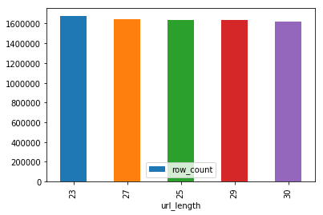

```python
length_stat.plot(kind="bar", x="url_length", y="row_count")

plt.show()
```

```python
log_with_domains = log_with_regions.withColumn("domain", f.regexp_extract("url", "http:\/\/(.*)\/", 1))
```

```python
log_with_domains.show(2, False, True)
```

```
-RECORD 0----------------------------------------------------------------------------------------------------
 ip        | 222.131.187.37
 timestamp | 20140112193801
 url       | http://news.mail.ru/7703130
 size      | 903
 code      | 504
 ua        | Chrome/5.0 (compatible; MSIE 9.0; Windows NT 6.1; Win64; x64; Trident/5.0; .NET CLR 3.5.30729;)
 region    | Kaluga Oblast
 domain    | news.mail.ru
-RECORD 1----------------------------------------------------------------------------------------------------
 ip        | 222.131.187.37
 timestamp | 20140112193801
 url       | http://news.mail.ru/7703130
 size      | 903
 code      | 504
 ua        | Chrome/5.0 (compatible; MSIE 9.0; Windows NT 6.1; Win64; x64; Trident/5.0; .NET CLR 3.5.30729;)
 region    | Yamalo-Nenets
 domain    | news.mail.ru
only showing top 2 rows
```

## Есть ли корреляция между `url_length` и `domain`?

```python
length_stat = log_with_domains.groupBy(f.length("url").alias("url_length"), "domain")\
                              .agg(f.count("*").alias("row_count"))\
                              .orderBy("row_count", ascending=False)\
                              .toPandas()
```

```python
length_stat
```

|  | url_length | domain | row_count |
| --- | --- | --- | --- |
| 0 | 23 | lenta.ru | 1676363 |
| 1 | 27 | news.mail.ru | 1644000 |
| 2 | 25 | newsru.com | 1639043 |
| 3 | 29 | news.yandex.ru | 1638174 |
| 4 | 30 | news.rambler.ru | 1617023 |

```python
log_with_domains[log_with_domains.domain == "lenta.ru"][["url"]].show(3, False)
```

```
+-----------------------+
|url                    |
+-----------------------+
|http://lenta.ru/1741564|
|http://lenta.ru/1741564|
|http://lenta.ru/1741564|
+-----------------------+
only showing top 3 rows
```

```python
log_with_domains.withColumn("url_length", f.length("url")).corr("domain", "url_length")
```

[output not shown]

Упс, нужна доп. предобработка самописные функциями

## User Defined Functions

UDF может иметь один из следующих типов:

- **SCALAR**. scalar UDF задает transformation: Одну или несколько `pandas.Series` -> `pandas.Series`. Scalar UDFs используются с `pyspark.sql.DataFrame.withColumn()` и `pyspark.sql.DataFrame.select()`
- **GROUPED_MAP**.grouped map UDF задает transformation: A `pandas.DataFrame` -> A `pandas.DataFrame`. Grouped map UDFs используются с `pyspark.sql.GroupedData.apply()`

```python
log_with_domains[["domain"]].distinct().collect()
```

```
[Row(domain='news.rambler.ru'),
 Row(domain='news.yandex.ru'),
 Row(domain='newsru.com'),
 Row(domain='news.mail.ru'),
 Row(domain='lenta.ru')]
```

```python
                # тип возврщаемого значения
@f.pandas_udf(IntegerType())
def encode_domain(domains):
    mapping = {
        'lenta.ru': 0,
        'newsru.com': 1,
        'news.mail.ru': 2,
        'news.yandex.ru': 3,
        'news.rambler.ru': 4
    }
    return domains.apply(lambda x: mapping.get(x))
```

```python
log_with_domains.withColumn("domain_encoded", encode_domain("domain")).show(3, vertical=True, truncate=False)
```

```
-RECORD 0---------------------------------------------------------------------------------------------------------
 ip             | 222.131.187.37
 timestamp      | 20140112193801
 url            | http://news.mail.ru/7703130
 size           | 903
 code           | 504
 ua             | Chrome/5.0 (compatible; MSIE 9.0; Windows NT 6.1; Win64; x64; Trident/5.0; .NET CLR 3.5.30729;)
 region         | Kaluga Oblast
 domain         | news.mail.ru
 domain_encoded | 2
-RECORD 1---------------------------------------------------------------------------------------------------------
 ip             | 222.131.187.37
 timestamp      | 20140112193801
 url            | http://news.mail.ru/7703130
 size           | 903
 code           | 504
 ua             | Chrome/5.0 (compatible; MSIE 9.0; Windows NT 6.1; Win64; x64; Trident/5.0; .NET CLR 3.5.30729;)
 region         | Yamalo-Nenets
 domain         | news.mail.ru
 domain_encoded | 2
-RECORD 2---------------------------------------------------------------------------------------------------------
 ip             | 222.131.187.37
 timestamp      | 20140112193801
 url            | http://news.mail.ru/7703130
 size           | 903
 code           | 504
 ua             | Chrome/5.0 (compatible; MSIE 9.0; Windows NT 6.1; Win64; x64; Trident/5.0; .NET CLR 3.5.30729;)
 region         | Yaroslavl Oblast
 domain         | news.mail.ru
 domain_encoded | 2
only showing top 3 rows
```

```python
log_with_domains.withColumn("domain_encoded", encode_domain("domain"))\
                .withColumn("url_length", f.length("url"))\
                .corr("domain_encoded", "url_length")
```

```
0.9939371499380237
```

```python
log_with_domains.filter(f.isnull("url")).count()
```

```
0
```

```python
log_with_domains.groupby("domain").agg(f.min(f.length("url")), f.max(f.length("url"))).show()
```

```
+---------------+----------------+----------------+
|         domain|min(length(url))|max(length(url))|
+---------------+----------------+----------------+
|news.rambler.ru|              30|              30|
| news.yandex.ru|              29|              29|
|     newsru.com|              25|              25|
|   news.mail.ru|              27|              27|
|       lenta.ru|              23|              23|
+---------------+----------------+----------------+
```

```python
spark.stop()
```

# Lecture 4

# Vectors

```python
import os
import sys
os.environ["PYSPARK_PYTHON"]='/opt/anaconda/envs/bd9/bin/python'
os.environ["SPARK_HOME"]='/usr/hdp/current/spark2-client'
os.environ["PYSPARK_SUBMIT_ARGS"]='--num-executors 3 pyspark-shell'

spark_home = os.environ.get('SPARK_HOME', None)

sys.path.insert(0, os.path.join(spark_home, 'python'))
sys.path.insert(0, os.path.join(spark_home, 'python/lib/py4j-0.10.7-src.zip'))
```

```python
from pyspark import SparkConf
from pyspark.sql import SparkSession

conf = SparkConf()
conf.set("spark.app.name", "app")

spark = SparkSession.builder.config(conf=conf).getOrCreate()
```

```python
spark
```

**SparkSession - in-memory**

**SparkContext**

[Spark UI](http://spark-master-5.newprolab.com:4043)

**Version**

`v2.4.7`

**Master**

`yarn`

**AppName**

`app`

```python
%pylab inline
```

```python
from pyspark.ml.linalg import DenseVector, SparseVector
```

```python
v2 = DenseVector([[1, 2], [2, 3], [3, 4]])
```

```python
v = DenseVector([1, 2, 3, 4])
```

```python
v / 2
```

```
DenseVector([0.5, 1.0, 1.5, 2.0])
```

```python
type(v)
```

```
pyspark.ml.linalg.DenseVector
```

```python
print(type(v2), type(v2[0]))
```

```
<class 'pyspark.ml.linalg.DenseVector'> <class 'numpy.ndarray'>
```

```python
v.values
```

```
array([1., 2., 3., 4.])
```

```python
type(v.values)
```

```
numpy.ndarray
```

```python
v.toArray()
```

```
array([1., 2., 3., 4.])
```

```python
type(v.toArray())
```

```
numpy.ndarray
```

Пока все хорошо, но как только будут вектора большого размера или нули все станет не оч

Для этого есть Sparse Vector

## Indexing

```python
v[0]
```

```
1.0
```

```python
v[-1]
```

```
4.0
```

```python
v[2:4]
```

```
array([3., 4.])
```

```python
v2[2, 0]
```

```
3.0
```

## Operations

```python
v - 2
```

```
DenseVector([-1.0, 0.0, 1.0, 2.0])
```

```python
v / 3
```

```
DenseVector([0.3333, 0.6667, 1.0, 1.3333])
```

## L1 norm

```python
v.norm(1)
```

```
10.0
```

```python
(v * -1).norm(1) == v.norm(1)
```

```
True
```

## L2 norm

```python
type(v)
```

```
pyspark.ml.linalg.DenseVector
```

```python
v.norm(2)
```

```
5.477225575051661
```

```python
v.norm(0)
```

```
4.0
```

```python
v.values[0] = 0
```

```python
v
```

```
DenseVector([0.0, 2.0, 3.0, 4.0])
```

```python
from pyspark.ml.linalg import Vectors
```

```python
u = Vectors.dense([1, 2, 3, 5])
```

```python
u
```

```
DenseVector([1.0, 2.0, 3.0, 5.0])
```

```python
v - u
```

```
DenseVector([-1.0, 0.0, 0.0, -1.0])
```

```python
v.squared_distance(u)
```

```
2.0
```

## Cosine similarity

```python
v.dot(u) / (v.norm(2) * u.norm(2))
```

```
0.9812567051925868
```

Таким образом, мы не ограничены в операциях, можем проделывать почти все операции из Numpy

## Sparse vectors

```python
from pyspark.ml.linalg import Vectors
```

```python
ndx_value = tuple(zip(range(4), range(1, 5)))
```

```python
ndx_value
```

```
((0, 1), (1, 2), (2, 3), (3, 4))
```

```python
type(ndx_value)
```

```
tuple
```

Храним как индекс элемента: значение элемента

```python
v = SparseVector(len(ndx_value), ndx_value)
```

```python
v
```

```
SparseVector(4, {0: 1.0, 1: 2.0, 2: 3.0, 3: 4.0})
```

```python
DenseVector(v)
```

```
DenseVector([1.0, 2.0, 3.0, 4.0])
```

```python
#         размер , индексы не нулевых элементов, значения не нулевых элеметнов
v = Vectors.sparse(11, [0, 2, 4, 10], [1, 2, 3, 5])
v
```

```
SparseVector(11, {0: 1.0, 2: 2.0, 4: 3.0, 10: 5.0})
```

```python
d = DenseVector(v)
d
```

```
DenseVector([1.0, 0.0, 2.0, 0.0, 3.0, 0.0, 0.0, 0.0, 0.0, 0.0, 5.0])
```

```python
u = SparseVector(4, range(4), [10, 100, 1000, 1000])
u
```

```
SparseVector(4, {0: 10.0, 1: 100.0, 2: 1000.0, 3: 1000.0})
```

```python
d = DenseVector(u)
d
```

```
DenseVector([10.0, 100.0, 1000.0, 1000.0])
```

```python
v * 2
```

```
---------------------------------------------------------------------------
TypeError                                 Traceback (most recent call last)
<ipython-input-367-4b985d5c1c9d> in <module>()
----> 1 v * 2

TypeError: unsupported operand type(s) for *: 'SparseVector' and 'int'
```

```python
v - u
```

```
---------------------------------------------------------------------------
TypeError                                 Traceback (most recent call last)
<ipython-input-368-bb2bb0c08723> in <module>()
----> 1 v - u

TypeError: unsupported operand type(s) for -: 'SparseVector' and 'SparseVector'
```

```python
v.squared_distance(u)
```

```
---------------------------------------------------------------------------
AssertionError                            Traceback (most recent call last)
<ipython-input-369-0c72cff0ae7a> in <module>()
----> 1 v.squared_distance(u)

/usr/hdp/current/spark2-client/python/pyspark/ml/linalg/__init__.py in squared_distance(self, other)
    638         AssertionError: dimension mismatch
    639         """
--> 640         assert len(self) == _vector_size(other), "dimension mismatch"
    641
    642         if isinstance(other, np.ndarray) or isinstance(other, DenseVector):

AssertionError: dimension mismatch
```

```python
v.dot(u) / (v.norm(2) * u.norm(2))
```

```
---------------------------------------------------------------------------
AssertionError                            Traceback (most recent call last)
<ipython-input-370-19586e96bf30> in <module>()
----> 1 v.dot(u) / (v.norm(2) * u.norm(2))

/usr/hdp/current/spark2-client/python/pyspark/ml/linalg/__init__.py in dot(self, other)
    595             return np.dot(self.values, other[self.indices])
    596
--> 597         assert len(self) == _vector_size(other), "dimension mismatch"
    598
    599         if isinstance(other, DenseVector):

AssertionError: dimension mismatch
```

Есть ограничения на операции, но данные можем хранить большие обьемы данных

```python
spark.stop()
```

# ML Pipeline

```python
import os
import sys
os.environ["PYSPARK_PYTHON"]='/opt/anaconda/envs/bd9/bin/python'
os.environ["SPARK_HOME"]='/usr/hdp/current/spark2-client'
## запрашиваем больше ресурсов
os.environ["PYSPARK_SUBMIT_ARGS"]='--num-executors 5 --executor-memory 4g --driver-memory 3g pyspark-shell'

spark_home = os.environ.get('SPARK_HOME', None)

sys.path.insert(0, os.path.join(spark_home, 'python'))
sys.path.insert(0, os.path.join(spark_home, 'python/lib/py4j-0.10.7-src.zip'))
```

```python
from pyspark import SparkConf
from pyspark.sql import SparkSession

conf = SparkConf()
conf.set("spark.app.name", "Sergey Grishaev ML app")

spark = SparkSession.builder.config(conf=conf).getOrCreate()

from IPython.display import Image
```

## Pipeline

- **DataFrame**: ML API использует DataFrame из Spark SQL как dataset, в котором могут храниться признаки, метки классов, предсказания.
- **Transformer**: Transformer это алгоритм, который может преобразовать один DataFrame в другой DataFrame. Например, ML model это Transformer, который преобразовывает DataFrame с признаками в другой DataFrame с предсказаниями.
- **Estimator**: Estimator это алгоритм, который может быть обучен на DataFrame, чтобы создать Transformer. Например, алгоритм обучения это - Estimator, который обучается на DataFrame и создает модель.
- **Pipeline**: Pipeline соединяет в цепочку несколько Transformers и Estimators вместе, чтобы задать ML workflow.
- **Parameter**: Все Transformers и Estimators теперь имеют общее API для спецификации параметров.

По сути Transformer & Estimator еще новая абстракция над данными, которая позволяет делать код более читабельным и высокоуровневым

Т.е все то же самое можно сделать и на rdd, но будет куча кода

[figure not shown]

Spark ML хорош для

- подготовки данных
  - аггрегаций, feature engineering
- после в паркеты и на обучение

```python
from pyspark.ml.linalg import Vectors
from pyspark.ml.classification import LogisticRegression
```

```python
training_set = spark.createDataFrame([
    (1.0, Vectors.dense([0.0, 1.1, 0.1])),
    (0.0, Vectors.dense([2.0, 1.0, -1.0])),
    (0.0, Vectors.dense([2.0, 1.3, 1.0])),
    (1.0, Vectors.dense([0.0, 1.2, -0.5]))], schema = ["label", "features"])
```

```python
training_set.printSchema()
```

```
root
 |-- label: double (nullable = true)
 |-- features: vector (nullable = true)
```

```python
training_set.show(2)
```

```
+-----+--------------+
|label|      features|
+-----+--------------+
|  1.0| [0.0,1.1,0.1]|
|  0.0|[2.0,1.0,-1.0]|
+-----+--------------+
only showing top 2 rows
```

schema может указываться как выше, и Spark сам будет определять типы данных, так лучше не делать и жестко указать типы данных

```python
from pyspark.sql.types import StructType, StructField, DoubleType
from pyspark.ml.linalg import VectorUDT
```

```python
schema = StructType(fields=[
    StructField("label", DoubleType()),
    StructField("features", VectorUDT()),
])
```

```python
training_set = spark.createDataFrame([
    (1.0, Vectors.dense([0.0, 1.1, 0.1])),
    (0.0, Vectors.dense([2.0, 1.0, -1.0])),
    (0.0, Vectors.dense([2.0, 1.3, 1.0])),
    (1.0, Vectors.dense([0.0, 1.2, -0.5]))], schema=schema)
```

```python
training_set.printSchema()
```

```
root
 |-- label: double (nullable = true)
 |-- features: vector (nullable = true)
```

```python
# задаем Estimator - можно обучить на данных и получить модель
lr = LogisticRegression(maxIter=10, regParam=0.01)
```

```python
lr
```

```
LogisticRegression_db0a9142a373
```

```python
lr.params[:2]
```

```
[Param(parent='LogisticRegression_db0a9142a373', name='aggregationDepth', doc='suggested depth for treeAggregate (>= 2).'),
 Param(parent='LogisticRegression_db0a9142a373', name='elasticNetParam', doc='the ElasticNet mixing parameter, in range [0, 1]. For alpha = 0, the penalty is an L2 penalty. For alpha = 1, it is an L1 penalty.')]
```

# Что за регуляризационный параметр тут используется?

```python
lr.getOrDefault('regParam')
```

```
0.01
```

```python
lr.getOrDefault('standardization')
```

```
True
```

```python
model = lr.fit(training_set)
```

```python
type(model) ## -- Transformer, подав DF с фичами, получим предсказания
```

```
pyspark.ml.classification.LogisticRegressionModel
```

```python
dir(model)[-5:]
```

```
['uid',
 'upperBoundsOnCoefficients',
 'upperBoundsOnIntercepts',
 'weightCol',
 'write']
```

```python
model.coefficients
```

```
DenseVector([-3.1009, 2.6082, -0.3802])
```

```python
model.interceptVector
```

```
DenseVector([0.0682])
```

```python
predict = model.transform(training_set)
```

```python
predict.printSchema()
```

```
root
 |-- label: double (nullable = true)
 |-- features: vector (nullable = true)
 |-- rawPrediction: vector (nullable = true)
 |-- probability: vector (nullable = true)
 |-- prediction: double (nullable = false)
```

```python
training_set.show(1)
```

```
+-----+-------------+
|label|     features|
+-----+-------------+
|  1.0|[0.0,1.1,0.1]|
+-----+-------------+
only showing top 1 row
```

```python
predict.show(1, truncate=False, vertical=True)
```

```
-RECORD 0-------------------------------------------------
 label         | 1.0
 features      | [0.0,1.1,0.1]
 rawPrediction | [-2.8991948946380295,2.8991948946380295]
 probability   | [0.05219337666300748,0.9478066233369925]
 prediction    | 1.0
only showing top 1 row
```

rawPrediction это внутрянка Spark, есть формула позв перевести в probability

Почему единичка, а вот почему

```python
model.getOrDefault("threshold")
```

```
0.5
```

## Toxic Comment Classification Challenge

```python
from pyspark.sql.types import StringType, IntegerType
```

```python
schema = StructType([
    StructField("id", StringType()),
    StructField("comment_text", StringType()),
    StructField("toxic", IntegerType()),
    StructField("severe_toxic", IntegerType()),
    StructField("obscene", IntegerType()),
    StructField("threat", IntegerType()),
    StructField("insult", IntegerType()),
    StructField("identity_hate", IntegerType())
])
```

```python
! hdfs dfs -head /lectures/lecture03/data/train.csv
```

```
"id","comment_text","toxic","severe_toxic","obscene","threat","insult","identity_hate"
"0000997932d777bf","Explanation
Why the edits made under my username Hardcore Metallica Fan were reverted? They weren't vandalisms, just closure on some GAs after I voted at New York Dolls FAC. And please don't remove the template from the talk page since I'm retired now.89.205.38.27",0,0,0,0,0,0
"000103f0d9cfb60f","D'aww! He matches this background colour I'm seemingly stuck with. Thanks.  (talk) 21:51, January 11, 2016 (UTC)",0,0,0,0,0,0
"000113f07ec002fd","Hey man, I'm really not trying to edit war. It's just that this guy is constantly removing relevant information and talking to me through edits instead of my talk page. He seems to care more about the formatting than the actual info.",0,0,0,0,0,0
"0001b41b1c6bb37e","""
More
I can't make any real suggestions on improvement - I wondered if the section statistics should be later on, or a subsection of """"types of accidents""""  -I think the references may need tidying so
```

```python
dataset = spark.read.csv("/lectures/lecture03/data/train.csv",
                         schema=schema,
                         header=True)
```

```python
dataset.show(2)
```

```
+--------------------+--------------------+-----+------------+-------+------+------+-------------+
|                  id|        comment_text|toxic|severe_toxic|obscene|threat|insult|identity_hate|
+--------------------+--------------------+-----+------------+-------+------+------+-------------+
|    0000997932d777bf|         Explanation| null|        null|   null|  null|  null|         null|
|Why the edits mad...| just closure on ...|    0|           0|      0|     0|     0|            0|
+--------------------+--------------------+-----+------------+-------+------+------+-------------+
only showing top 2 rows
```

```python
dataset.show(2, vertical=True)
```

```
-RECORD 0-----------------------------
 id            | 0000997932d777bf
 comment_text  | Explanation
 toxic         | null
 severe_toxic  | null
 obscene       | null
 threat        | null
 insult        | null
 identity_hate | null
-RECORD 1-----------------------------
 id            | Why the edits mad...
 comment_text  |  just closure on ...
 toxic         | 0
 severe_toxic  | 0
 obscene       | 0
 threat        | 0
 insult        | 0
 identity_hate | 0
only showing top 2 rows
```

## Был баг с multiline CSVs, fix в 2.2.0 https://issues.apache.org/jira/browse/SPARK-19610

```python
dataset = spark.read.csv("/lectures/lecture03/data/train.csv",
                         schema=schema, header=True, multiLine=True)
```

```python
dataset.show(2, vertical=True)
```

```
-RECORD 0-----------------------------
 id            | 0000997932d777bf
 comment_text  | Explanation
Why t...
 toxic         | 0
 severe_toxic  | 0
 obscene       | 0
 threat        | 0
 insult        | 0
 identity_hate | 0
-RECORD 1-----------------------------
 id            | 000103f0d9cfb60f
 comment_text  | D'aww! He matches...
 toxic         | 0
 severe_toxic  | 0
 obscene       | 0
 threat        | 0
 insult        | 0
 identity_hate | 0
only showing top 2 rows
```

```python
dataset.select("id").show(10)
```

```
+--------------------+
|                  id|
+--------------------+
|    0000997932d777bf|
|    000103f0d9cfb60f|
|    000113f07ec002fd|
|    0001b41b1c6bb37e|
|                More|
|I can't make any ...|
|There appears to ...|
|    0001d958c54c6e35|
|    00025465d4725e87|
|Congratulations f...|
+--------------------+
only showing top 10 rows
```

## Необходимо добавить `escape` параметр!

```python
dataset = spark.read.csv("/lectures/lecture03/data/train.csv",
                         schema=schema, header=True, multiLine=True, escape='"')
```

```python
dataset.select("id").distinct().show(5)
```

```
+----------------+
|              id|
+----------------+
|002264ea4d5f2887|
|0149abcca732f2e7|
|02412f4f3b9872ae|
|028aa892076cf0d1|
|0310c62027c1cc81|
+----------------+
only showing top 5 rows
```

```python
dataset.show(2, vertical=True, truncate=False)
```

```
-RECORD 0---------------------------------------------------------------------------------------------------------------------------------------------------------------------------------------------------------------------------------------------------------------------------------
 id            | 0000997932d777bf
 comment_text  | Explanation
Why the edits made under my username Hardcore Metallica Fan were reverted? They weren't vandalisms, just closure on some GAs after I voted at New York Dolls FAC. And please don't remove the template from the talk page since I'm retired now.89.205.38.27
 toxic         | 0
 severe_toxic  | 0
 obscene       | 0
 threat        | 0
 insult        | 0
 identity_hate | 0
-RECORD 1---------------------------------------------------------------------------------------------------------------------------------------------------------------------------------------------------------------------------------------------------------------------------------
 id            | 000103f0d9cfb60f
 comment_text  | D'aww! He matches this background colour I'm seemingly stuck with. Thanks.  (talk) 21:51, January 11, 2016 (UTC)
 toxic         | 0
 severe_toxic  | 0
 obscene       | 0
 threat        | 0
 insult        | 0
 identity_hate | 0
only showing top 2 rows
```

```python
dataset.rdd.getNumPartitions()
```

```
1
```

```python
dataset.count()
```

```
159571
```

```python
dataset = dataset.repartition(10)
dataset.rdd.getNumPartitions()
```

```
10
```

## Определим бинарный target (toxic/non-toxic)

```python
from pyspark.sql import functions as f
```

```python
# если хотя бы один параметр равен одному, то коммент токсичный
target = f.when(
    (dataset.toxic == 0) &
    (dataset.severe_toxic == 0) &
    (dataset.obscene == 0) &
    (dataset.threat == 0) &
    (dataset.insult == 0) &
    (dataset.identity_hate == 0),
    0
).otherwise(1)
```

```python
dataset = dataset.withColumn("target", target)
```

```python
dataset.select("id", "target").show(5)
```

```
+----------------+------+
|              id|target|
+----------------+------+
|85e4f353ca4b2bde|     0|
|56433e47a0818849|     0|
|01c0ae884d69319b|     0|
|438e69256e644081|     0|
|7b65f1b25caab0cc|     0|
+----------------+------+
only showing top 5 rows
```

```python
dataset.filter(f.col('id') == 'de3c112d4f18ca80').show(2,
                                                      vertical=True,
                                                      truncate=False)
```

```
-RECORD 0---------------------------------------------------------------------------------------------------------------------------------------------------------------------------------------------------------------------------------------------------------------------------------------------------…
 id           | de3c112d4f18ca80
 comment_text | Make A Deal

Why have an edit war?

My edit in Now 86

is okay of course

You are just big dicks

and now I fell so bad

This is the worst I've had

Yeah...........

Make a Deal (x3)

Yeah, yeah

Make a Deal (x3)

Yeah............

I'm called GMTV around the globe

I've been lost and have goten a great big strobe

It ain't cool

I've been a man

And now I should take over the land

I'm an only child

It so ain't fair

```

[output cut: 81 more lines]

```

Yeah, yeah

Make a Deal (x3)

Yeah............

Make a Deal (x3)

Yeah, yeah

Make a Deal (x3)

Yeah............
 target       | 1
```

```python
dataset.groupBy('target').count().collect()
```

```
[Row(target=1, count=16225), Row(target=0, count=143346)]
```

```python
16225 / (16225 + 143346)
```

```
0.10167887648758234
```

```python
dataset = dataset.drop("toxic", "severe_toxic", "obscene", "threat", "insult", "identity_hate").cache()
```

```python
dataset.count()
```

```
159571
```

```python
dataset.show(2, False, True)
```

```
-RECORD 0---------------------------------------------------------------------------------------------------------------------------------------------------------------------------------------------------------------------------------------------------------------------------------------------------…
 id           | 85e4f353ca4b2bde
 comment_text | Arthur Rose Eldred GA Sweeps: On Hold
I have reviewed Arthur Rose Eldred for GA Sweeps to determine if it still qualifies as a Good Article. In reviewing the article I have found several issues, which I have detailed here. Since you are a main contributor of the article (determined based on this tool), I figured you would be interested …
 target       | 0
-RECORD 1---------------------------------------------------------------------------------------------------------------------------------------------------------------------------------------------------------------------------------------------------------------------------------------------------…
 id           | 56433e47a0818849
 comment_text | Please remove my images, it's obvious you're trying to get a rise out of me.
 target       | 0
only showing top 2 rows
```

```python
dataset.write.parquet("/tmp/ruslan.nagimov/comments_dataset_tmp",
                      mode="overwrite")
```

## Обучим самую простую binary logistic regression

```python
from pyspark.ml.feature import Tokenizer, HashingTF
```

## Преобразуем комметарии в слова

```python
tokenizer = Tokenizer(inputCol="comment_text", outputCol="words")
```

```python
dataset2 = tokenizer.transform(dataset)
```

```python
dataset2
```

```
DataFrame[id: string, comment_text: string, target: int, words: array<string>]
```

```python
dataset2.select('id', 'words').show(2)
```

```
+----------------+--------------------+
|              id|               words|
+----------------+--------------------+
|85e4f353ca4b2bde|[arthur, rose, el...|
|56433e47a0818849|[please, remove, ...|
+----------------+--------------------+
only showing top 2 rows
```

```python
dataset2.take(1)
```

```
[Row(id='85e4f353ca4b2bde', comment_text="Arthur Rose Eldred GA Sweeps: On Hold\nI have reviewed Arthur Rose Eldred for GA Sweeps to determine if it still qualifies as a Good Article. In reviewing the article I have found several issues, which I have detailed here. Since you are a main contributor o…
```

```python
type(dataset2.take(1))
```

```
list
```

```python
type(dataset2.take(1)[0])
```

```
pyspark.sql.types.Row
```

```python
type(dataset2.take(1)[0].words)
```

```
list
```

```python
dataset2.take(1)[0].words[:2]
```

```
['arthur', 'rose']
```

# Hashing trick vs CountVectorizer

```python
df = spark.createDataFrame(
    [
    (0, "PYTHON HIVE HIVE".split(" ")),
    (1, "JAVA JAVA SQL".split(" "))
    ],
    ["id", "words"])

df.show(truncate = False)
```

```
+---+--------------------+
|id |words               |
+---+--------------------+
|0  |[PYTHON, HIVE, HIVE]|
|1  |[JAVA, JAVA, SQL]   |
+---+--------------------+
```

```python
from pyspark.ml.feature import CountVectorizer

cv = CountVectorizer(inputCol="words", outputCol="features")

# нужен fit - сформируется словарик
model = cv.fit(df)
result = model.transform(df)

result.show(truncate=False)
```

```
+---+--------------------+-------------------+
|id |words               |features           |
+---+--------------------+-------------------+
|0  |[PYTHON, HIVE, HIVE]|(4,[0,3],[2.0,1.0])|
|1  |[JAVA, JAVA, SQL]   |(4,[1,2],[2.0,1.0])|
+---+--------------------+-------------------+
```

Обучили CountVectorizer, он сформировал следующий словарик:

```
{0: "HIVE", 1: "JAVA", 2: "SQL", 3: "PYTHON"}
```

```
(4,[0,3],[2.0,1.0]) - 4 значения,
                      [0, 3] - не нулевые индексы в словаре,
                      [2.0, 1.0] - кол-во
```

```python
from pyspark.ml.feature import HashingTF
                                                    # рез-т хэширования делится на 4
ht = HashingTF(inputCol="words", outputCol="features", numFeatures=4)
# fit не нужен
result = ht.transform(df)

result.show(truncate=False)
```

```
+---+--------------------+-------------------+
|id |words               |features           |
+---+--------------------+-------------------+
|0  |[PYTHON, HIVE, HIVE]|(4,[0],[3.0])      |
|1  |[JAVA, JAVA, SQL]   |(4,[2,3],[1.0,2.0])|
+---+--------------------+-------------------+
```

HashingTF - он быстрее, т.к не нужно обучать, но при малом numFeatures он схлопывает слова.

Bидно что PYTHON и HIVE схлопнулись в одно слово -- т.к совпал значения хеш % numFeatures

```python
from pyspark.ml.feature import HashingTF

ht = HashingTF(inputCol="words", outputCol="features", numFeatures=20)
result = ht.transform(df)

result.show(truncate=False)
```

```
+---+--------------------+---------------------+
|id |words               |features             |
+---+--------------------+---------------------+
|0  |[PYTHON, HIVE, HIVE]|(20,[0,12],[2.0,1.0])|
|1  |[JAVA, JAVA, SQL]   |(20,[2,19],[1.0,2.0])|
+---+--------------------+---------------------+
```

## Преобразуем тексты в бинарные вектора, используя hashing trick

```python
hasher = HashingTF(numFeatures=100,
                   binary=True,
                   inputCol=tokenizer.getOutputCol(),
                   outputCol="word_vector")
```

```python
dataset2 = hasher.transform(dataset2)
```

```python
dataset2.select("id", "word_vector").show(2, False, True)
```

```
-RECORD 0---------------------------------------------------------------------------------------------------------------------------------------------------------------------------------------------------------------------------------------------------------------------------------------------------…
 id          | 85e4f353ca4b2bde
 word_vector | (100,[0,7,9,10,14,15,16,22,23,25,27,28,29,30,31,33,36,37,38,40,41,43,44,45,46,47,50,55,56,59,62,63,64,68,70,71,72,73,76,79,80,82,84,85,86,88,89,91,92,94,95,96,97,99],[1.0,1.0,1.0,1.0,1.0,1.0,1.0,1.0,1.0,1.0,1.0,1.0,1.0,1.0,1.0,1.0,1.0,1.0,1.0,1.0,1.0,1.0,1.0,1.0,1.0,1.0,1.0,1.0,1.0,1.…
-RECORD 1---------------------------------------------------------------------------------------------------------------------------------------------------------------------------------------------------------------------------------------------------------------------------------------------------…
 id          | 56433e47a0818849
 word_vector | (100,[13,16,30,32,34,37,41,43,54,59,70,88,91],[1.0,1.0,1.0,1.0,1.0,1.0,1.0,1.0,1.0,1.0,1.0,1.0,1.0])
only showing top 2 rows
```

```python
hasher_freq = HashingTF(numFeatures=100,
                        binary=False,
                        inputCol=tokenizer.getOutputCol(),
                        outputCol="word_vector_freq")

dataset2_freq = hasher_freq.transform(dataset2)
```

```python
dataset2_freq.select("id", "word_vector_freq").show(2, False, True)
```

```
-RECORD 0---------------------------------------------------------------------------------------------------------------------------------------------------------------------------------------------------------------------------------------------------------------------------------------------------…
 id               | 85e4f353ca4b2bde
 word_vector_freq | (100,[0,7,9,10,14,15,16,22,23,25,27,28,29,30,31,33,36,37,38,40,41,43,44,45,46,47,50,55,56,59,62,63,64,68,70,71,72,73,76,79,80,82,84,85,86,88,89,91,92,94,95,96,97,99],[3.0,2.0,1.0,4.0,1.0,1.0,1.0,1.0,1.0,9.0,3.0,1.0,5.0,1.0,1.0,1.0,1.0,1.0,1.0,2.0,3.0,1.0,1.0,4.0,1.0,4.0,1.0,1.0,2…
-RECORD 1---------------------------------------------------------------------------------------------------------------------------------------------------------------------------------------------------------------------------------------------------------------------------------------------------…
 id               | 56433e47a0818849
 word_vector_freq | (100,[13,16,30,32,34,37,41,43,54,59,70,88,91],[1.0,2.0,1.0,1.0,1.0,1.0,1.0,1.0,1.0,1.0,1.0,2.0,1.0])
only showing top 2 rows
```

## Разобъем наши данные на train и test, не забывая о том, что классы не сбалансированные

```python
dataset2.show(2)
```

```
+----------------+--------------------+------+--------------------+--------------------+
|              id|        comment_text|target|               words|         word_vector|
+----------------+--------------------+------+--------------------+--------------------+
|85e4f353ca4b2bde|Arthur Rose Eldre...|     0|[arthur, rose, el...|(100,[0,7,9,10,14...|
|56433e47a0818849|Please remove my ...|     0|[please, remove, ...|(100,[13,16,30,32...|
+----------------+--------------------+------+--------------------+--------------------+
only showing top 2 rows
```

```python
train = dataset2.sampleBy("target",
                          fractions={0: 0.8, 1: 0.8},
                          seed=5757)
```

```python
train.groupby("target").count().collect()
```

```
[Row(target=1, count=13028), Row(target=0, count=115017)]
```

```python
13028 / (13028 + 115017)
```

```
0.1017454801046507
```

```python
test = dataset2.join(train, on="id", how="leftanti")
```

```python
test.groupby("target").count().collect()
```

```
[Row(target=1, count=3197), Row(target=0, count=28329)]
```

```python
3197 / (3197 + 28329)
```

```
0.10140836135253442
```

```python
train.rdd.getNumPartitions()
```

```
10
```

```python
test.rdd.getNumPartitions()
```

```
200
```

У теста 200 партиций, т.к получили его через Джойн

```python
train
```

```
DataFrame[id: string, comment_text: string, target: int, words: array<string>, word_vector: vector]
```

```python
train = train.drop("comment_text", "words").cache()
train
```

```
DataFrame[id: string, target: int, word_vector: vector]
```

```python
test = test.drop("comment_text", "words").coalesce(10).cache()
test
```

```
DataFrame[id: string, target: int, word_vector: vector]
```

## Обучим logistic regression

```python
from pyspark.ml.classification import LogisticRegression
```

```python
lr = LogisticRegression(featuresCol=hasher.getOutputCol(),
                        labelCol="target",
                        maxIter=15)
```

```python
lr
```

```
LogisticRegression_7a70007461e5
```

```python
lr_model = lr.fit(train)
```

```python
lr_model
```

```
LogisticRegressionModel: uid = LogisticRegression_7a70007461e5, numClasses = 2, numFeatures = 100
```

```python
predictions = lr_model.transform(test)
```

```python
predictions
```

```
DataFrame[id: string, target: int, word_vector: vector, rawPrediction: vector, probability: vector, prediction: double]
```

```python
predictions.select("id",
                   "target",
                   "prediction",
                   "probability",
                   "rawPrediction").\
                    show(5, False, True)
```

```
-RECORD 0--------------------------------------------------
 id            | 002264ea4d5f2887
 target        | 1
 prediction    | 0.0
 probability   | [0.9381469881849404,0.06185301181505969]
 rawPrediction | [2.719145847424567,-2.719145847424567]
-RECORD 1--------------------------------------------------
 id            | 0349af3c0c3d960c
 target        | 0
 prediction    | 0.0
 probability   | [0.9876496054653803,0.012350394534619747]
 rawPrediction | [4.381639975819104,-4.381639975819104]
-RECORD 2--------------------------------------------------
 id            | 03a0e6449ff06683
 target        | 0
 prediction    | 0.0
 probability   | [0.9898011589142788,0.010198841085721132]
 rawPrediction | [4.575229978585976,-4.575229978585976]
-RECORD 3--------------------------------------------------
 id            | 04a694ffe26cbaee
 target        | 0
 prediction    | 0.0
 probability   | [0.8199548502640739,0.18004514973592609]
 rawPrediction | [1.5160416267854238,-1.5160416267854238]
-RECORD 4--------------------------------------------------
 id            | 06e0ff3a1ae1e792
 target        | 0
 prediction    | 0.0
 probability   | [0.9498039407057715,0.05019605929422856]
 rawPrediction | [2.940319061589804,-2.940319061589804]
only showing top 5 rows
```

```python
correct_predictions = predictions.select("target",
                                         f.col("prediction")
                                         .cast("int")).filter("target == prediction").count()

correct_predictions
```

```
28364
```

```python
all_predictions = predictions.count()

all_predictions
```

```
31526
```

```python
true_positive = predictions.select("target", f.col("prediction").cast("int"))\
           .filter((f.col("target") == 1) & (f.col("prediction") == f.col("target")))\
           .count()

false_positive = predictions.select("target", f.col("prediction").cast("int"))\
           .filter((f.col("prediction") == 1) & (f.col("prediction") != f.col("target")))\
           .count()

false_negative = predictions.select("target", f.col("prediction").cast("int"))\
           .filter((f.col("prediction") == 0) & (f.col("prediction") != f.col("target")))\
           .count()


print(f"Accuracy is {correct_predictions / all_predictions}")
print(f'Precision is {true_positive / (true_positive + false_positive)}')
print(f'Recall is {true_positive / (true_positive + false_negative)}')
```

```
Accuracy is 0.8997018334073463
Precision is 0.5757575757575758
Recall is 0.041601501407569595
```

**Получим то же самое, но через Sklearn**

```python
from sklearn.metrics import classification_report

predictions_pd = predictions.select("target", f.col("prediction").cast("int")).toPandas()
predictions_pd.head(4)
```

|  | target | prediction |
| --- | --- | --- |
| 0 | 1 | 0 |
| 1 | 0 | 0 |
| 2 | 0 | 0 |
| 3 | 0 | 0 |

```python
print(classification_report(predictions_pd.target, predictions_pd.prediction))
```

```
             precision    recall  f1-score   support

          0       0.90      1.00      0.95     28329
          1       0.58      0.04      0.08      3197

avg / total       0.87      0.90      0.86     31526
```

## Что, если мы хотим более надежные метрики?

```python
from pyspark.ml.evaluation import BinaryClassificationEvaluator
```

```python
evaluator = BinaryClassificationEvaluator(rawPredictionCol="rawPrediction",
                                          labelCol="target",
                                          metricName='areaUnderROC')
```

```python
predictions.show(4)
```

```
+----------------+------+--------------------+--------------------+--------------------+----------+
|              id|target|         word_vector|       rawPrediction|         probability|prediction|
+----------------+------+--------------------+--------------------+--------------------+----------+
|002264ea4d5f2887|     1|(100,[1,3,7,8,10,...|[2.71914584742456...|[0.93814698818494...|       0.0|
|0349af3c0c3d960c|     0|(100,[6,7,8,9,10,...|[4.38163997581910...|[0.98764960546538...|       0.0|
|03a0e6449ff06683|     0|(100,[0,3,9,10,13...|[4.57522997858597...|[0.98980115891427...|       0.0|
|04a694ffe26cbaee|     0|(100,[17,26,41,49...|[1.51604162678542...|[0.81995485026407...|       0.0|
+----------------+------+--------------------+--------------------+--------------------+----------+
only showing top 4 rows
```

```python
# Roc-Auc
print(f'ROC-AUC is {evaluator.evaluate(predictions)}')
```

```
ROC-AUC is 0.7602701138427573
```

```python
evaluator = BinaryClassificationEvaluator(rawPredictionCol="probability",
                                          labelCol="target",
                                          metricName='areaUnderROC')
```

```python
print(f'ROC-AUC is {evaluator.evaluate(predictions)}')
```

```
ROC-AUC is 0.7602701138427577
```

```python
evaluator.setParams(metricName="precision")
```

```
BinaryClassificationEvaluator_6d5580f0283b
```

```python
evaluator.evaluate(predictions)
```

[output not shown]

[output cut: 24 more lines]

[output not shown]

## `spark.ml.evaluation.BinaryClassificationEvaluator` подсчитывает только ROC AUC и PR AUC. Что, если мы хотим больше?

```python
from pyspark.ml.evaluation import MulticlassClassificationEvaluator
```

```python
evaluator = MulticlassClassificationEvaluator(predictionCol="prediction",
                                              labelCol="target",
                                              metricName="f1")
```

```python
evaluator.evaluate(predictions)
```

```
0.8588061351516327
```

```python
evaluator = evaluator.setMetricName("weightedPrecision")
evaluator.evaluate(predictions)
```

```
0.8689998468858822
```

```python
evaluator = evaluator.setMetricName("weightedRecall")
evaluator.evaluate(predictions)
```

```
0.8997018334073463
```

## Определим pipeline!

```python
dataset = spark.read.parquet("/lectures/lecture03/data/dataset")
```

```python
dataset.show(2, True, True)
```

```
-RECORD 0----------------------------
 id           | 6fdb7b6734f8bf40
 comment_text | "

""Katara""
I'v...
 target       | 0
-RECORD 1----------------------------
 id           | 26e1b63617df36b1
 comment_text | "

 charlie wilso...
 target       | 0
only showing top 2 rows
```

```python
hasher = HashingTF(numFeatures=100, binary=True, inputCol=tokenizer.getOutputCol(), outputCol="word_vector")
```

```python
dataset.rdd.getNumPartitions()
```

```
4
```

```python
from pyspark.ml import Pipeline
```

```python
pipeline = Pipeline(stages=[
    tokenizer,
    hasher,
    lr]
                   )
```

```python
train = dataset.sampleBy("target", fractions={0: 0.8, 1: 0.8}, seed=42).cache()
test = dataset.join(train, on="id", how="leftanti").coalesce(10).cache()
```

```python
pipeline_model = pipeline.fit(train)
```

```python
pipeline_model
```

```
PipelineModel_e7d63d9b9aad
```

```python
predictions = pipeline_model.transform(test)
```

```python
evaluator.evaluate(predictions)
```

```
0.8976095241094768
```

## Добавим фичей

```python
pipeline_model.stages
```

```
[Tokenizer_d3883bdef8ec,
 HashingTF_075990704791,
 LogisticRegressionModel: uid = LogisticRegression_7a70007461e5, numClasses = 2, numFeatures = 100]
```

```python
# увеличим размерность для векторов
pipeline_model = pipeline.fit(train, params={hasher.numFeatures: 200})
```

```python
pipeline_model.stages
```

```
[Tokenizer_d3883bdef8ec,
 HashingTF_075990704791,
 LogisticRegressionModel: uid = LogisticRegression_7a70007461e5, numClasses = 2, numFeatures = 200]
```

```python
pipeline_model.stages[1].extractParamMap()
```

```
{Param(parent='HashingTF_075990704791', name='binary', doc='If True, all non zero counts are set to 1. This is useful for discrete probabilistic models that model binary events rather than integer counts. Default False.'): True,
 Param(parent='HashingTF_075990704791', name='numFeatures', doc='number of features.'): 200,
 Param(parent='HashingTF_075990704791', name='outputCol', doc='output column name.'): 'word_vector',
 Param(parent='HashingTF_075990704791', name='inputCol', doc='input column name.'): 'words'}
```

```python
predictions = pipeline_model.transform(test)
evaluator.evaluate(predictions)
```

```
0.9029006960410696
```

## Больше фичей!

```python
from pyspark.ml.feature import VectorAssembler
import pyspark.sql.functions as f
```

```python
hasher = HashingTF(numFeatures=200,
                   binary=True,
                   inputCol=tokenizer.getOutputCol(),
                   outputCol="word_vector")
```

```python
dataset.printSchema()
```

[output not shown]

```python
# добавим фичу - длина комментария
dataset = dataset.withColumn("comment_length", f.length(dataset.comment_text))
```

```python
train = dataset.sampleBy("target", fractions={0: 0.8, 1: 0.8}, seed=42).cache()
test = dataset.join(train, on="id", how="leftanti").coalesce(10).cache()
```

```python
train
```

```
DataFrame[id: string, comment_text: string, target: int, comment_length: int]
```

```python
assembler = VectorAssembler(inputCols=[hasher.getOutputCol(), "comment_length"],
                            outputCol="features")
```

```python
pipeline = Pipeline(stages=[
    tokenizer,
    hasher,
    assembler,
    lr
])
```

```python
pipeline_model = pipeline.fit(train)
```

```python
pipeline_model.stages
```

```
[Tokenizer_d3883bdef8ec,
 HashingTF_92cf6ad07165,
 VectorAssembler_3fd8341713ab,
 LogisticRegressionModel: uid = LogisticRegression_7a70007461e5, numClasses = 2, numFeatures = 200]
```

```python
predictions = pipeline_model.transform(test)
```

```python
evaluator.evaluate(predictions)
```

```
0.9029006960410696
```

```python
pipeline_model.stages[-1].coefficients[-1]
```

```
1.123823294308251
```

```python
len(pipeline_model.stages[-1].coefficients)
```

```
200
```

## Ok, так как было правильно!? https://www.kaggle.com/c/jigsaw-toxic-comment-classification-challenge/discussion/52557

## В любом случае, у нас еще не иссякли идеи)

```python
from pyspark.ml.feature import CountVectorizer
```

```python
count_vectorizer = CountVectorizer(inputCol=tokenizer.getOutputCol(),
                                   outputCol="word_vector",
                                   binary=True)
```

```python
count_vectorizer.params
```

```
[Param(parent='CountVectorizer_dfdac5932bea', name='binary', doc='Binary toggle to control the output vector values. If True, all nonzero counts (after minTF filter applied) are set to 1. This is useful for discrete probabilistic models that model binary events rather than integer counts. Default Fa…
 Param(parent='CountVectorizer_dfdac5932bea', name='inputCol', doc='input column name.'),
 Param(parent='CountVectorizer_dfdac5932bea', name='maxDF', doc='Specifies the maximum number of different documents a term could appear in to be included in the vocabulary. A term that appears more than the threshold will be ignored. If this is an integer >= 1, this specifies the maximum number of …
 Param(parent='CountVectorizer_dfdac5932bea', name='minDF', doc='Specifies the minimum number of different documents a term must appear in to be included in the vocabulary. If this is an integer >= 1, this specifies the number of documents the term must appear in; if this is a double in [0,1), then …
 Param(parent='CountVectorizer_dfdac5932bea', name='minTF', doc="Filter to ignore rare words in a document. For each document, terms with frequency/count less than the given threshold are ignored. If this is an integer >= 1, then this specifies a count (of times the term must appear in the document)…
 Param(parent='CountVectorizer_dfdac5932bea', name='outputCol', doc='output column name.'),
 Param(parent='CountVectorizer_dfdac5932bea', name='vocabSize', doc='max size of the vocabulary. Default 1 << 18.')]
```

```python
assembler = VectorAssembler(inputCols=[count_vectorizer.getOutputCol(),
                                       "comment_length"],
                            outputCol="features")
```

```python
pipeline = Pipeline(stages=[
    tokenizer,
    count_vectorizer,
    assembler,
    lr
])
```

```python
lr.getOrDefault("regParam")
```

```
0.0
```

```python
pipeline_model = pipeline.fit(train)
```

```python
predictions = pipeline_model.transform(test)
evaluator.evaluate(predictions)
```

```
0.949387420868634
```

## Hyperparameter tuning

```python
from pyspark.ml.tuning import CrossValidator, ParamGridBuilder
```

```python
# Перебор параметров
paramGrid = ParamGridBuilder().addGrid(lr.maxIter, [15])\
                              .addGrid(lr.regParam, [0.01, 0.05])\
                              .build()
```

```python
paramGrid
```

```
[{Param(parent='LogisticRegression_7a70007461e5', name='maxIter', doc='max number of iterations (>= 0).'): 15,
  Param(parent='LogisticRegression_7a70007461e5', name='regParam', doc='regularization parameter (>= 0).'): 0.01},
 {Param(parent='LogisticRegression_7a70007461e5', name='maxIter', doc='max number of iterations (>= 0).'): 15,
  Param(parent='LogisticRegression_7a70007461e5', name='regParam', doc='regularization parameter (>= 0).'): 0.05}]
```

```python
crossval = CrossValidator(estimator=pipeline, estimatorParamMaps=paramGrid,
                              evaluator=evaluator, numFolds=3, parallelism=5)
```

```python
cv_model = crossval.fit(train)
```

[output not shown]

```python
cv_model.avgMetrics
```

```
---------------------------------------------------------------------------
NameError                                 Traceback (most recent call last)
<ipython-input-608-512f18159691> in <module>()
----> 1 cv_model.avgMetrics

NameError: name 'cv_model' is not defined
```

```python
dir(cv_model.bestModel)
```

```
['__class__',
 '__delattr__',
 '__dict__',
 '__dir__',
 '__doc__',
 '__eq__',
 '__format__',
 '__ge__',
 '__getattribute__',
 '__gt__',
 '__hash__',
 '__init__',
 '__init_subclass__',
 '__le__',
 '__lt__',
 '__metaclass__',
 '__module__',
 '__ne__',
 '__new__',
 '__reduce__',
 '__reduce_ex__',
 '__repr__',
 '__setattr__',
 '__sizeof__',
 '__str__',
 '__subclasshook__',
 '__weakref__',
 '_clear',
 '_copyValues',
 '_copy_params',
 '_defaultParamMap',
 '_dummy',
 '_from_java',
 '_paramMap',
 '_params',
 '_randomUID',
 '_resetUid',
 '_resolveParam',
 '_set',
 '_setDefault',
 '_shouldOwn',
 '_to_java',
 '_transform',
 'copy',
 'explainParam',
 'explainParams',
 'extractParamMap',
 'getOrDefault',
 'getParam',
 'hasDefault',
 'hasParam',
 'isDefined',
 'isSet',
 'load',
 'params',
 'read',
 'save',
 'set',
 'stages',
 'transform',
 'uid',
 'write']
```

```python
cv_model.avgMetrics
```

[output not shown]

```python
predictions = cv_model.transform(test)
```

```python
evaluator.evaluate(predictions)
```

```
0.9480016377436931
```

Модели, которые запущены на Spark - хорошо параллеляться, но не так много алгоритмов МЛ, которые считаются параллельно

И параллеляться, но выгрыш по времени далеко не линейный

# Попробуем более сложные модели

```python
from pyspark.ml.classification import GBTClassifier

gbt = GBTClassifier(featuresCol=hasher.getOutputCol(), labelCol="target")

pipeline = Pipeline(stages=[
    tokenizer,
    hasher,
    assembler,
    gbt
])

pipeline_model = pipeline.fit(train)

predictions = pipeline_model.transform(test)

evaluator.evaluate(predictions)
```

```
0.9000661396491448
```

```python
paramGrid = ParamGridBuilder().addGrid(gbt.maxIter, [10, 15])\
                              .addGrid(gbt.maxDepth, [7, 9])\
                              .addGrid(gbt.stepSize, [0.2, 0.25])\
                              .build()
```

```python
crossval = CrossValidator(estimator=pipeline,
                          estimatorParamMaps=paramGrid,
                          evaluator=evaluator,
                          numFolds=3,
                          parallelism=3)
```

```python
cv_model = crossval.fit(train)
```

```python
cv_model.avgMetrics
```

```
[0.9039714463684126,
 0.9044728432494751,
 0.9036114957950763,
 0.903009477457466,
 0.9051062456665846,
 0.9052468018705719,
 0.9042609440516136,
 0.9037454223469232]
```

```python
cv_model.bestModel
```

```
PipelineModel_f446ef1f0681
```

```python
predictions = cv_model.transform(test)
```

```python
evaluator.evaluate(predictions)
```

```
0.9027432206859626
```

```python
spark.stop()
```

```
---------------------------------------------------------------------------
NameError                                 Traceback (most recent call last)
<ipython-input-1-5c6b4d5d9db0> in <module>()
----> 1 spark.stop()

NameError: name 'spark' is not defined
```

## Clustering

```python
import os
import sys

os.environ["PYSPARK_SUBMIT_ARGS"]='--num-executors 5 --executor-memory 4g --driver-memory 3g pyspark-shell'
os.environ["PYSPARK_PYTHON"]='/opt/anaconda/envs/bd9/bin/python'
os.environ["SPARK_HOME"]='/usr/hdp/current/spark2-client'

spark_home = os.environ.get('SPARK_HOME', None)

if not spark_home:
    raise ValueError('SPARK_HOME environment variable is not set')

sys.path.insert(0, os.path.join(spark_home, 'python'))
sys.path.insert(0, os.path.join(spark_home, 'python/lib/py4j-0.10.7-src.zip'))
```

```python
from pyspark import SparkConf
from pyspark.sql import SparkSession

conf = SparkConf()
conf.set("spark.app.name", "app")

spark = SparkSession.builder.config(conf=conf).getOrCreate()
```

```python
spark
```

**SparkSession - in-memory**

**SparkContext**

[Spark UI](http://spark-master-5.newprolab.com:4054)

**Version**

`v2.4.7`

**Master**

`yarn`

**AppName**

`app`

```python
from pyspark.sql.types import StructType, StructField, StringType, IntegerType
```

```python
schema = StructType([
    StructField("id", StringType()),
    StructField("comment_text", StringType()),
    StructField("toxic", IntegerType()),
    StructField("severe_toxic", IntegerType()),
    StructField("obscene", IntegerType()),
    StructField("threat", IntegerType()),
    StructField("insult", IntegerType()),
    StructField("identity_hate", IntegerType())
])
```

```python
dataset = spark.read.csv("/lectures/lecture03/data/train.csv",
                         schema=schema,
                         header=True,
                         multiLine=True,
                         escape='"')
```

```python
dataset = dataset.repartition(10).cache()
```

```python
dataset
```

```
DataFrame[id: string, comment_text: string, toxic: int, severe_toxic: int, obscene: int, threat: int, insult: int, identity_hate: int]
```

```python
from pyspark.ml.feature import Tokenizer, StopWordsRemover, CountVectorizer
```

```python
tokenizer = Tokenizer(inputCol="comment_text", outputCol="words")
```

```python
stop_words = StopWordsRemover.loadDefaultStopWords("english")
```

```python
swr = StopWordsRemover(inputCol=tokenizer.getOutputCol(),
                       outputCol="words_filtered",
                       stopWords=stop_words)
```

```python
# ограничиваем словарь слов до 20_000
count_vectorizer = CountVectorizer(inputCol=swr.getOutputCol(),
                                   outputCol="word_vector",
                                   vocabSize=20_000)
```

```python
from pyspark.ml import Pipeline
```

```python
preprocessing = Pipeline(stages=[
    tokenizer,
    swr,
    count_vectorizer
])
```

```python
preprocessing_model = preprocessing.fit(dataset)
```

```python
preprocessed_dataset = preprocessing_model.transform(dataset)
```

```python
preprocessed_dataset.select(["word_vector"]).show(3, truncate=False)
```

```
+-----------------------------------------------------------------------------------------------------------------------------------------------------------------------------------------------------------------------------------------------------------------------------------------------------------…
|word_vector                                                                                                                                                                                                                                                                                                …
+-----------------------------------------------------------------------------------------------------------------------------------------------------------------------------------------------------------------------------------------------------------------------------------------------------------…
|(20000,[0,2,3,4,9,13,18,22,43,44,49,53,70,105,113,128,148,156,225,244,260,299,362,451,524,527,773,1068,1109,1290,1647,1681,1772,1798,2172,2208,2243,2543,3002,3131,3322,4224,5113,5562,8857],[1.0,3.0,1.0,1.0,1.0,1.0,1.0,1.0,1.0,2.0,1.0,1.0,1.0,1.0,1.0,1.0,1.0,1.0,1.0,1.0,1.0,1.0,1.0,1.0,1.0,1.0,1.0,1…
|(20000,[4,18,106,111,139,601,3095,3781],[1.0,1.0,1.0,1.0,1.0,1.0,1.0,1.0])                                                                                                                                                                                                                                 …
|(20000,[0,25,28,39,352],[2.0,1.0,1.0,1.0,1.0])                                                                                                                                                                                                                                                             …
+-----------------------------------------------------------------------------------------------------------------------------------------------------------------------------------------------------------------------------------------------------------------------------------------------------------…
only showing top 3 rows
```

```python
dataset
```

```
DataFrame[id: string, comment_text: string, toxic: int, severe_toxic: int, obscene: int, threat: int, insult: int, identity_hate: int]
```

```python
from pyspark.ml.clustering import KMeans
```

```python
kmeans = KMeans(featuresCol="word_vector", k=7, seed=5757)
```

```python
kmeans_model = kmeans.fit(preprocessed_dataset)
```

```python
clustering = kmeans_model.transform(preprocessed_dataset)
```

```python
clustering[clustering.columns[2:8] + ["prediction"]].take(10)
```

```
[Row(toxic=0, severe_toxic=0, obscene=0, threat=0, insult=0, identity_hate=0, prediction=0),
 Row(toxic=0, severe_toxic=0, obscene=0, threat=0, insult=0, identity_hate=0, prediction=0),
 Row(toxic=0, severe_toxic=0, obscene=0, threat=0, insult=0, identity_hate=0, prediction=0),
 Row(toxic=0, severe_toxic=0, obscene=0, threat=0, insult=0, identity_hate=0, prediction=0),
 Row(toxic=0, severe_toxic=0, obscene=0, threat=0, insult=0, identity_hate=0, prediction=0),
 Row(toxic=0, severe_toxic=0, obscene=0, threat=0, insult=0, identity_hate=0, prediction=0),
 Row(toxic=0, severe_toxic=0, obscene=0, threat=0, insult=0, identity_hate=0, prediction=0),
 Row(toxic=0, severe_toxic=0, obscene=0, threat=0, insult=0, identity_hate=0, prediction=0),
 Row(toxic=0, severe_toxic=0, obscene=0, threat=0, insult=0, identity_hate=0, prediction=0),
 Row(toxic=0, severe_toxic=0, obscene=0, threat=0, insult=0, identity_hate=0, prediction=0)]
```

Что-то не очень - ничего не разметилось, как оценить кластеризацию ?

### Silhouette score

https://en.wikipedia.org/wiki/Silhouette_(clustering)

```python
from pyspark.ml.evaluation import ClusteringEvaluator
```

```python
evaluator = ClusteringEvaluator(featuresCol="word_vector")
```

```python
evaluator.evaluate(clustering)
```

```
0.9036143800801032
```

```python
# посмотрим на кластеры
clustering.filter(clustering.prediction.isin([1, 2]))[["comment_text", "prediction"]].show(2,
                                                                            truncate=False,
                                                                            vertical=True)
```

```
-RECORD 0---------------------------------------------------------------------------------------------------------------------------------------------------------------------------------------------------------------------------------------------------------------------------------------------------…
 comment_text | "

Also I had nothing to do in this war:

 Byron Wilcott and David Otunga were removed and then readded to the list five times.

 Dos Caras, Jr. was removed and then readded to the list seven times.

 Jason Riggs and Johnny Riggs were removed and then readded to the list four times.

 Glamarella was added and then removed from the list three times.

 Matt Walsh and Mike Hutter were added and then removed from the list three times.

 Chad Lail was added and then removed from the list three times.

Probably the third?

Anyway, everyone edited, more or less it matters not, all that matters is were we are and it's all our falt. WE have done this and we'll get out of it. Please don't treat me like a vandal or anything. I participated, and I don't see it fair that you say four editors were in the war, it was well more…

It was stated above that while other editors were making edits to the page those edits were not what contributed to the conflict that caused the page to be protected. And regarding your issues with Elkman and your block, I don't see an issue there. Tiptoey blocked you and Nikki311 (upon your request…

I'm moving the discussion  so that other contributors can edit in peace (Matt, your comment  please). jan€₣

You're suggesting that you move the discussion regarding this article off of the articles talkpage?   Matt

Yes because as you see this thing is getting heated up, it would cause a bad impression. jan€₣

Definitely not. Discussion goes HERE, this is the talkpage, not a page is your userpage.

Oh god there are more rules here than in Naziland (Germany in WWII). Anyway, lets see, let's reach a consensus here. Now, we unblock the page, and if a user fires up a war, let he be blocked, not the page. My issues with Elkman started in april and it was all a mistake (Contact me Elkman). Let's say…

And the thread is Godwinned. Anyway, the policy is not for an immediate ban. An editor is to be warned and a ban may result if the editor in question does not stop the behavior they received the warning for.   Matt

Yah, but they weren't even warned, just because I vandalized a page about 8M ago it dosen't mean I can't turn a new leaf. jan€₣

You were warned for your edits repeatedly and disregarded them. Some of the edits done were good faith reversions, which while violating 3RR may not warrant warnings if it's to revert vandalism. Now, if we c
 prediction   | 1
-RECORD 1---------------------------------------------------------------------------------------------------------------------------------------------------------------------------------------------------------------------------------------------------------------------------------------------------…
```

[output cut: 60 more lines]

```

It means, there wasn't a CTV National News before then.

Doesn't make sense

The article says:
""Jennings also attended Carleton University, University of Ottawa, and Rider College in New Jersey. He never graduated from high school or college.""

How is that possible? He attended universities but never graduated Highschool..

Trust me, as someone with a chequered educational career, I can affirm that it is possible to get into college without a diploma. Many post secondary institutions have 'special student' part time or night school programs with relaxed entrance requirements. Of course, it helps that his dad was a bigw…

I am an alumni of Carleton, until recently,  if one was out of school for a couple of years you could sign up as a ""special Student"" and if you did well in a couple of courses, you could then apply as a ""Mature Student"" with no consideration of your previous education required.
 prediction   | 1
only showing top 2 rows
```

Упростим задачу, задав только 2 кластера

```python
kmeans = KMeans(featuresCol="word_vector", k=2, seed=1234)
kmeans_model = kmeans.fit(preprocessed_dataset)
clustering = kmeans_model.transform(preprocessed_dataset)
evaluator.evaluate(clustering)
```

```
0.9940200541366592
```

```python
kmeans_model.clusterCenters()
```

```
[array([2.83177406e+00, 5.11735379e-01, 2.43699062e-01, ...,
        1.25579234e-04, 1.31858196e-04, 1.38137158e-04]),
 array([1.55288026e+02, 5.50161812e-01, 6.60194175e-01, ...,
        6.47249191e-03, 3.23624595e-03, 0.00000000e+00])]
```

```python
import numpy as np
```

```python
kmeans_model.clusterCenters()[1]
```

```
array([1.55288026e+02, 5.50161812e-01, 6.60194175e-01, ...,
       6.47249191e-03, 3.23624595e-03, 0.00000000e+00])
```

```python
np.argsort(kmeans_model.clusterCenters()[1])
```

```
array([19999,  7795,  7796, ...,  1107,   370,     0])
```

```python
preprocessing_model.stages[2].vocabulary
```

[output not shown]

[output cut: 946 more lines]

```
 'easy',
 'february',
 'civil',
 'barnstar',
 'november',
 'amount',
 'article?',
 'space',
 'damn',
 'wonder',
 'ass.',
 'finding',
 'became',
 'chance',
 ...]
```

```python
for i in np.argsort(kmeans_model.clusterCenters()[1])[:40]:
    print(preprocessing_model.stages[2].vocabulary[i])
```

```
case;
accusations,
trend
noticeboard.
clock
dominant
oppose.
metal,
garage
font
joy
racist.
musicians
jasenm222
transgender
ani,
enjoying
london,
sued
ever,
slang
reflection
making.
style=""background-color:white;""
hist)
delay
dogmatic
(let's
check.
lands
stark
concede
outrageous
copy.
him/her
beliefs.
labeling
remarkable
designated
ambiguity
```

```python
for i in np.argsort(kmeans_model.clusterCenters()[1])[-40:]:
    print(preprocessing_model.stages[2].vocabulary[i])
```

```
"
talk
is.
====
j.delanoy
keep
unblock
must
please
/
wikipedia
egg
one
article
fack
bad
wanker
sexual.
page
•
notrhbysouthbanof
cocks
all!!
nigger
anal
nikko
smells
rape
fggt!
you?
sucks
fuck
homo
like
know
-
tacos
die
```

```python
for i in np.argsort(kmeans_model.clusterCenters()[0])[:40]:
    print(preprocessing_model.stages[2].vocabulary[i])
```

```
edie
enyclopedia!!!!!!!!!!!!!!!!!!!!!!!!!!!!!!!!!!!!!!!!
farted,
misterwiki.
cingular
hellor
shannon!
11/27
biznitch
mangina!
(speedy
die!!!!!!!!!!!!
nikko
notrhbysouthbanof
i7)
shikoku
71.15.159.191
2+2=5
oi!!
dickhead!
1.5%
j.delanoy
sexual.
18:42
brother!
lovers.68.79.118.61
battalion,
(city)
b:
all!!
tacos
cline
otherwords
keller
frm
248-678-9807
paterson,
d:
wikipedians!!
],
```

```python
for i in np.argsort(kmeans_model.clusterCenters()[0])[-40:]:
    print(preprocessing_model.stages[2].vocabulary[i])
```

```
say
thanks
really
name
page.
find
made
many
first
information
go
thank
new
need
it.
time
want
good
articles
make
even
get
use
people
edit
may
know
also
see
think
talk
wikipedia
-
one
like
please
page
article
"
```

**The curse of dimensionality**

[figure not shown]

**Why is that?**

[figure not shown]

## LDA

[figure not shown]

- Попробуем побороть проклятие размерности

LDA метод

```python
from pyspark.ml.clustering import LDA
```

```python
lda = LDA(featuresCol="word_vector", seed=5757, k=7)

lda_model = lda.fit(preprocessed_dataset)
```

что происходит:

- проходим по нашим предложениям, сплитим их
- через CountVectorizer создаем вектора фичей -> большая размерность вектора
- натравливаем алгоритм кластеризации, LDA из размерности 20_000 сделает 7
- далее запихнем в LogisticRegr или Gradient Boosting

```python
topics = lda_model.transform(preprocessed_dataset)
```

```python
topics.show(5, vertical=True, truncate=False)
```

```
-RECORD 0---------------------------------------------------------------------------------------------------------------------------------------------------------------------------------------------------------------------------------------------------------------------------------------------------…
 id                | 85e4f353ca4b2bde
 comment_text      | Arthur Rose Eldred GA Sweeps: On Hold
I have reviewed Arthur Rose Eldred for GA Sweeps to determine if it still qualifies as a Good Article. In reviewing the article I have found several issues, which I have detailed here. Since you are a main contributor of the article (determined based on this tool), I figured you would be interested …
 toxic             | 0
 severe_toxic      | 0
 obscene           | 0
 threat            | 0
 insult            | 0
 identity_hate     | 0
 words             | [arthur, rose, eldred, ga, sweeps:, on, hold, i, have, reviewed, arthur, rose, eldred, for, ga, sweeps, to, determine, if, it, still, qualifies, as, a, good, article., in, reviewing, the, article, i, have, found, several, issues,, which, i, have, detailed, here., since, you, are…
 words_filtered    | [arthur, rose, eldred, ga, sweeps:, hold, reviewed, arthur, rose, eldred, ga, sweeps, determine, still, qualifies, good, article., reviewing, article, found, several, issues,, detailed, here., since, main, contributor, article, (determined, based, tool),, figured, interested, co…
 word_vector       | (20000,[0,2,3,4,9,13,18,22,43,44,49,53,70,105,113,128,148,156,225,244,260,299,362,451,524,527,773,1068,1109,1290,1647,1681,1772,1798,2172,2208,2243,2543,3002,3131,3322,4224,5113,5562,8857],[1.0,3.0,1.0,1.0,1.0,1.0,1.0,1.0,1.0,2.0,1.0,1.0,1.0,1.0,1.0,1.0,1.0,1.0,1.0,1.0,1.0,1.0,1…
 topicDistribution | [0.002083085686988872,0.0020835148024689,0.785212432447848,0.002197713996856347,0.20339465612769103,0.002885609914490559,0.0021429870236562842]
-RECORD 1---------------------------------------------------------------------------------------------------------------------------------------------------------------------------------------------------------------------------------------------------------------------------------------------------…
 id                | 56433e47a0818849
 comment_text      | Please remove my images, it's obvious you're trying to get a rise out of me.
 toxic             | 0
 severe_toxic      | 0
 obscene           | 0
 threat            | 0
 insult            | 0
 identity_hate     | 0
 words             | [please, remove, my, images,, it's, obvious, you're, trying, to, get, a, rise, out, of, me.]
 words_filtered    | [please, remove, images,, obvious, trying, get, rise, me.]
 word_vector       | (20000,[4,18,106,111,139,601,3095,3781],[1.0,1.0,1.0,1.0,1.0,1.0,1.0,1.0])
 topicDistribution | [0.012405016439339382,0.012405442446550254,0.9189146625269228,0.013101607842970757,0.01320591921563494,0.017202499074895277,0.012764852453686797]
-RECORD 2---------------------------------------------------------------------------------------------------------------------------------------------------------------------------------------------------------------------------------------------------------------------------------------------------…
 id                | 01c0ae884d69319b
 comment_text      | Thank you

I just wanted to say it.
 toxic             | 0
 severe_toxic      | 0
 obscene           | 0
 threat            | 0
 insult            | 0
 identity_hate     | 0
 words             | [thank, you, , , i, just, wanted, to, say, it.]
 words_filtered    | [thank, , , wanted, say, it.]
```

[output cut: 17 more lines]

```
-RECORD 4---------------------------------------------------------------------------------------------------------------------------------------------------------------------------------------------------------------------------------------------------------------------------------------------------…
 id                | 7b65f1b25caab0cc
 comment_text      | Movie removal from the Hans Zimmer page.
Sorry got to reply to you so late.  I removed the film The Whole Wide World from Hans Zimmer's Filmography because IMDB's files on Hans Zimmer and the film did not listed him as one of the composers.
 toxic             | 0
 severe_toxic      | 0
 obscene           | 0
 threat            | 0
 insult            | 0
 identity_hate     | 0
 words             | [movie, removal, from, the, hans, zimmer, page., , sorry, got, to, reply, to, you, so, late., , i, removed, the, film, the, whole, wide, world, from, hans, zimmer's, filmography, because, imdb's, files, on, hans, zimmer, and, the, film, did, not, listed, him, as, one, of, the, c…
 words_filtered    | [movie, removal, hans, zimmer, page., , sorry, got, reply, late., , removed, film, whole, wide, world, hans, zimmer's, filmography, imdb's, files, hans, zimmer, film, listed, one, composers.]
 word_vector       | (20000,[0,6,35,129,149,221,242,272,276,659,713,940,1341,2169,2464,9832,10388,14419],[2.0,1.0,1.0,1.0,1.0,1.0,1.0,1.0,1.0,1.0,2.0,1.0,1.0,1.0,1.0,3.0,1.0,1.0])
 topicDistribution | [0.0048146387842087895,0.0048142956316442964,0.3217330518973705,0.005078518885531484,0.14238501252869795,0.5162211920121627,0.004953290260384298]
only showing top 5 rows
```

```python
lda_model.vocabSize()
```

```
20000
```

```python
lda_model.describeTopics(maxTermsPerTopic=10).collect()
```

```
[Row(topic=0, termIndices=[175, 200, 582, 752, 610, 2670, 0, 2641, 2943, 1107], termWeights=[0.036800545874656386, 0.02238283995940863, 0.019069027835485787, 0.013845080366067996, 0.011662025715391338, 0.010056030723642207, 0.009954599556866102, 0.009943992289150216, 0.008346460134983122, 0.00785849…
 Row(topic=1, termIndices=[0, 393, 153, 823, 1990, 105, 787, 684, 1201, 1082], termWeights=[0.03243142738072148, 0.017813785460761514, 0.012984306488454552, 0.012343562801576457, 0.010445168417549403, 0.009682427964124893, 0.008633126202041678, 0.007997767707271366, 0.007252526276890046, 0.006362407…
 Row(topic=2, termIndices=[0, 1, 2, 9, 5, 3, 8, 6, 10, 11], termWeights=[0.06706874545550452, 0.015191127506918523, 0.006944469406840791, 0.006055137151966535, 0.006043491445678825, 0.0059030182684193366, 0.005247042431192854, 0.005131526807536969, 0.004949219603663307, 0.00458022955327975]),
 Row(topic=3, termIndices=[0, 4, 59, 2, 1, 121, 3, 14, 69, 9], termWeights=[0.0677039452397092, 0.027567911158300432, 0.020001093143177887, 0.018986350817989973, 0.014594083299875774, 0.013844166605283056, 0.013194371637699058, 0.01260135933514214, 0.010997540503134222, 0.00821004984958361]),
 Row(topic=4, termIndices=[0, 4, 3, 17, 74, 1, 28, 8, 126, 56], termWeights=[0.0645160170246624, 0.01614407641632752, 0.01443946448368954, 0.01337066544478899, 0.013162640656984427, 0.010875395475988986, 0.010601283133527597, 0.009947239679568193, 0.00974880280561487, 0.008591449397883425]),
 Row(topic=5, termIndices=[0, 1, 2, 7, 6, 12, 5, 10, 13, 19], termWeights=[0.13519377834692223, 0.01711213006085042, 0.006398433424407819, 0.006092177058332844, 0.004799836972809231, 0.003616774463417769, 0.0035869297293367555, 0.002890700990582685, 0.0026330559449286362, 0.002394279800890077]),
 Row(topic=6, termIndices=[40, 249, 214, 211, 0, 379, 87, 567, 474, 359], termWeights=[0.03703017087007729, 0.027545608334289092, 0.02565603031281862, 0.022347484481900194, 0.017821663948564274, 0.017145571264261847, 0.014428534563788111, 0.01310129792137704, 0.01168395394542127, 0.01122967812180776…
```

Посмотрим, что вошло в каждый из топиков

```python
for i in [175, 200, 582, 752, 610, 2670, 0, 2641, 2943, 1107]:
    print(preprocessing_model.stages[-1].vocabulary[i])
```

```
u
hate
sucks
dick
pig
bitch!!fuck

you!!'fuck
ass!fuck
tacos
```

## Clustering is a good dimensionality reduction technique

```python
topics
```

```
DataFrame[id: string, comment_text: string, toxic: int, severe_toxic: int, obscene: int, threat: int, insult: int, identity_hate: int, words: array<string>, words_filtered: array<string>, word_vector: vector, topicDistribution: vector]
```

```python
from pyspark.sql import functions as f
from pyspark.ml.classification import LogisticRegression
from pyspark.ml.evaluation import BinaryClassificationEvaluator
```

```python
target = f.when(
    (topics.toxic == 0) &
    (topics.severe_toxic == 0) &
    (topics.obscene == 0) &
    (topics.threat == 0) &
    (topics.insult == 0) &
    (topics.identity_hate == 0),
    0
).otherwise(1)
```

```python
new_dataset = topics.withColumn("target", target)[["id", "target", "topicDistribution"]].cache()
```

```python
new_dataset.take(5)
```

```
[Row(id='85e4f353ca4b2bde', target=0, topicDistribution=DenseVector([0.0021, 0.0021, 0.7852, 0.0022, 0.2034, 0.0029, 0.0021])),
 Row(id='56433e47a0818849', target=0, topicDistribution=DenseVector([0.0124, 0.0124, 0.9189, 0.0131, 0.0132, 0.0172, 0.0128])),
 Row(id='01c0ae884d69319b', target=0, topicDistribution=DenseVector([0.016, 0.016, 0.8954, 0.0169, 0.017, 0.0222, 0.0165])),
 Row(id='438e69256e644081', target=0, topicDistribution=DenseVector([0.0032, 0.0032, 0.4473, 0.0033, 0.0034, 0.4838, 0.0559])),
 Row(id='7b65f1b25caab0cc', target=0, topicDistribution=DenseVector([0.0048, 0.0048, 0.3217, 0.0051, 0.1424, 0.5162, 0.005]))]
```

```python
lr = LogisticRegression(featuresCol="topicDistribution", labelCol="target")
```

```python
train = new_dataset.sampleBy("target", fractions={0: 0.8, 1: 0.8}, seed=5757).cache()
```

```python
test = new_dataset.join(train, on="id", how="leftanti").coalesce(10).cache()
```

```python
lr_model = lr.fit(train)
```

```python
predictions = lr_model.transform(test)
```

```python
evaluator = BinaryClassificationEvaluator(rawPredictionCol="probability",
                                          labelCol="target",
                                          metricName='areaUnderROC')
```

```python
evaluator.evaluate(predictions)
```

```
0.8361773017528845
```

```python
spark.stop()
```

# ALS

- раньше активно использовали в рекомендалках

```python
import os
import sys
os.environ["PYSPARK_SUBMIT_ARGS"]='--num-executors 5 --executor-memory 4g --driver-memory 3g pyspark-shell'
os.environ["PYSPARK_PYTHON"]='/opt/anaconda/envs/bd9/bin/python'
os.environ["SPARK_HOME"]='/usr/hdp/current/spark2-client'

spark_home = os.environ.get('SPARK_HOME', None)
if not spark_home:
    raise ValueError('SPARK_HOME environment variable is not set')
sys.path.insert(0, os.path.join(spark_home, 'python'))
sys.path.insert(0, os.path.join(spark_home, 'python/lib/py4j-0.10.7-src.zip'))
```

```python
from pyspark import SparkConf
from pyspark.sql import SparkSession

conf = SparkConf()
conf.set("spark.app.name", "app")

spark = SparkSession.builder.config(conf=conf).getOrCreate()
```

```python
spark
```

**SparkSession - in-memory**

**SparkContext**

[Spark UI](http://spark-master-5.newprolab.com:4043)

**Version**

`v2.4.7`

**Master**

`yarn`

**AppName**

`app`

## Наша цель представить матрицу user-item ratings как произведение двух матриц меньшего ранга

## $$R = U \times P^\top $$

## где

## $$U \in \mathbb{R}^{n \times k}, k \ll n$$

## и

## $$P \in \mathbb{R}^{m \times k}, k \ll m$$

## Как найти решение? Оптимизировать следующий функционал:

## $$J = \|R - U \times P^\top\|_2 + \lambda(\|U\|_2 + \|P\|_2)$$

## Возникают 2 проблемы:

- кол-во оптиимзируемых параметров $n \times k + m \times k$
- этот функционал non-convex (https://www.quora.com/Why-is-the-matrix-factorization-optimization-function-in-recommender-systems-not-convex)

## Что же делать? ALS (alternating least squares)

## обычный Least Squares

## $$J(\beta) = \|y - X\beta\|_2$$

## $$\beta = (X^\top X)^{-1}X^\top y$$

## ALS это 2-х шаговый итеративный процесс

## $$ \forall u_i : J(u_i) = \|R_i - u_i \times P^\top\|_2 + \lambda\|u_i\|_2$$

## $$ \forall p_j : J(p_j) = \|R_i - U \times p^{\top}_{j}\|_2 + \lambda\|p_j\|_2$$

## Решение следующее

## $$u_i = (P^\top \times P + \lambda I)^{-1} \times P^\top \times R_i$$

## $$p_j = (U^\top \times U + \lambda I)^{-1} \times U^\top \times R_j$$

```python
from pyspark.sql.types import StructType, StructField, IntegerType, LongType
from pyspark.ml.recommendation import ALS
from pyspark.ml.evaluation import RegressionEvaluator
import pyspark.sql.functions as f
```

```python
schema = StructType([
    StructField("user", IntegerType()),
    StructField("item", IntegerType()),
    StructField("rating", IntegerType()),
    StructField("timestamp", LongType())
])
```

```python
dataset = spark.read.csv("/lectures/lecture02/data/ml-100k/ua.base",
                         sep="\t",
                         schema=schema).drop("timestamp").repartition(20).cache()
```

```python
dataset.show(5)
```

```
+----+----+------+
|user|item|rating|
+----+----+------+
| 297|   1|     3|
| 119| 924|     4|
| 373| 230|     4|
| 900| 508|     3|
|  13| 828|     1|
+----+----+------+
only showing top 5 rows
```

```python
dataset.rdd.getNumPartitions()
```

```
20
```

```python
als = ALS(rank=10, maxIter=5, seed=5757)
```

```python
model = als.fit(dataset)
```

```python
model.rank
```

```
10
```

```python
test = spark.read.csv("/lectures/lecture02/data/ml-100k/ua.test",
                      sep="\t",
                      schema=schema).drop("timestamp").repartition(4).cache()
```

```python
predictions = model.transform(test)
predictions
```

```
DataFrame[user: int, item: int, rating: int, prediction: float]
```

```python
predictions.show(5)
```

```
+----+----+------+----------+
|user|item|rating|prediction|
+----+----+------+----------+
| 251| 148|     2|  3.038124|
| 580| 148|     4| 3.0317912|
| 602| 148|     4| 3.5022647|
| 372| 148|     5| 3.8346112|
| 274| 148|     2| 3.3601744|
+----+----+------+----------+
only showing top 5 rows
```

```python
# в качестве метрики возьмем RMSE
evaluator = RegressionEvaluator(labelCol="rating", metricName="rmse")
```

```python
evaluator.evaluate(predictions)
```

```
nan
```

Упс, проблема.. Нужно детальней посмотреть на данные

```python
predictions.groupBy("rating").count().show()
```

```
+------+-----+
|rating|count|
+------+-----+
|     1|  542|
|     3| 2424|
|     5| 2153|
|     4| 3316|
|     2|  995|
+------+-----+
```

```python
predictions.filter(f.isnan("prediction")).count()
```

```
2
```

Есть два prediction с nan

```python
predictions.filter(f.isnan("prediction")).show()
```

```
+----+----+------+----------+
|user|item|rating|prediction|
+----+----+------+----------+
| 675|1653|     5|       NaN|
| 405|1582|     1|       NaN|
+----+----+------+----------+
```

```python
print(dataset.filter(dataset.user == 675).show(2))
print(dataset.filter(dataset.user == 405).show(2))
print(dataset.filter(dataset.item == 1653).show(2))
print(dataset.filter(dataset.item == 1582).show(2))
```

```
+----+----+------+
|user|item|rating|
+----+----+------+
| 675| 235|     1|
| 675| 311|     3|
+----+----+------+
only showing top 2 rows

None
+----+----+------+
|user|item|rating|
+----+----+------+
| 405|  78|     2|
| 405|1227|     3|
+----+----+------+
only showing top 2 rows

None
+----+----+------+
|user|item|rating|
+----+----+------+
+----+----+------+

None
+----+----+------+
|user|item|rating|
+----+----+------+
+----+----+------+

None
```

Есть item, которые не смотрел ни один пользователь

```python
predictions = predictions.dropna()
```

```python
evaluator.evaluate(predictions)
```

```
0.9590533627741923
```

При старте какие-то значения могут быть не заполнены - холодный старт

Чтобы не исправлять вручную, можем заранее указать необходимый параметр

## Что делать с cold start в Spark?!

```python
model = als.fit(dataset, params={als.coldStartStrategy: "drop"})
```

```python
model.getOrDefault("coldStartStrategy")
```

```
'drop'
```

```python
predictions = model.transform(test)
```

```python
evaluator.evaluate(predictions)
```

```
0.9590533627741923
```

Получили тоже самое

## Можем ли мы лучше?

```python
model = als.fit(dataset, params={als.coldStartStrategy: "drop", als.maxIter: 20})
```

```python
predictions = model.transform(test)
```

```python
evaluator.evaluate(predictions)
```

```
0.9558872242636991
```

## А еще лучше?

```python
model = als.fit(dataset, params={als.coldStartStrategy: "drop", als.maxIter: 20, als.rank: 100})
```

```python
predictions = model.transform(test)
```

```python
evaluator.evaluate(predictions)
```

```
0.9475039684939921
```

## Заглянем внутрь?

```python
model.recommendForAllItems(5).show(2, False, True)
```

```
-RECORD 0-----------------------------------------------------------------------------------------------------
 item            | 1580
 recommendations | [[405, 0.9766721], [507, 0.8202009], [38, 0.8191449], [175, 0.8150184], [388, 0.79075205]]
-RECORD 1-----------------------------------------------------------------------------------------------------
 item            | 471
 recommendations | [[939, 4.7050047], [907, 4.6942906], [357, 4.6653857], [849, 4.568941], [532, 4.4908786]]
only showing top 2 rows
```

```python
model.recommendForAllUsers(5).show(3, False, True)
```

```
-RECORD 0-------------------------------------------------------------------------------------------------------
 user            | 471
 recommendations | [[932, 4.5933466], [8, 4.5158033], [422, 4.430621], [102, 4.418323], [465, 4.4073286]]
-RECORD 1-------------------------------------------------------------------------------------------------------
 user            | 463
 recommendations | [[19, 4.357951], [887, 4.278358], [1449, 4.2229476], [221, 4.2085767], [253, 4.199033]]
-RECORD 2-------------------------------------------------------------------------------------------------------
 user            | 833
 recommendations | [[1597, 4.580961], [1019, 4.3817782], [1187, 4.3798213], [589, 4.3486805], [488, 4.3081856]]
only showing top 3 rows
```

```python
model.itemFactors.show(2, False, True)
```

```
-RECORD 0---------------------------------------------------------------------------------------------------------------------------------------------------------------------------------------------------------------------------------------------------------------------------------------------------…
 id       | 10
 features | [-0.17320073, 0.1394914, 0.08175768, -0.020624358, 0.120475225, 0.086501904, -0.05590005, 0.671465, -0.004701962, -0.28409147, -0.26856878, -0.33872974, -0.1730683, 0.68844414, -0.012083569, 0.51397806, -0.16328637, -0.10118524, -0.029092629, -0.19808765, -0.21409819, 0.104427375, 0.0575…
-RECORD 1---------------------------------------------------------------------------------------------------------------------------------------------------------------------------------------------------------------------------------------------------------------------------------------------------…
 id       | 20
 features | [0.15676013, 0.14760819, -1.10948444E-4, -0.17182115, 0.21432161, -0.20783891, -0.5112587, 0.41280103, 0.16205746, -0.19493206, -0.14369382, -0.49176562, -0.29480222, 0.67348504, -0.36621276, 0.09152605, -0.09625394, 0.1916776, -0.028520966, -0.18675962, -0.27936405, 0.14118087, -0.10560…
only showing top 2 rows
```

```python
spark.stop()
```

# Lecture 5. ML Practical Part

## Функции First-Class Objects

```python
def salut(name):
    return f"Привет, {name}!"

def put_name(greeter_func):
    return greeter_func("всем")
```

```python
put_name(salut)
```

```
'Привет, всем!'
```

```python
def parent(num):
    def first_child():
        return "Привет, я Сергей."

    def second_child():
        return "Меня зовут Алексей."

    if num == 1:
        return first_child
    else:
        return second_child

parent(1)
```

```
<function __main__.parent.<locals>.first_child()>
```

```python
parent(1)()
```

```
'Привет, я Сергей.'
```

## Декораторы

A decorator is a function that takes another function and extends the behavior of the latter function without explicitly modifying it.

```python
def my_decorator(func):

    def wrapper():
        print("Что-то происходит до вызова функции.")
        func()
        print("Что-то происходит после вызова функции.")

    return wrapper

def say_piu():
    print("Пиу!")

say_piu = my_decorator(say_piu)
```

```python
say_piu
```

```
<function __main__.my_decorator.<locals>.wrapper()>
```

```python
say_piu()
```

```
Что-то происходит до вызова функции.
Пиу!
Что-то происходит после вызова функции.
```

```python
@my_decorator
def say_piu():
    print("Пиу!")
```

```python
say_piu()
```

```
Что-то происходит до вызова функции.
Пиу!
Что-то происходит после вызова функции.
```

## Декораторы для функций с аргументами

```python
def do_twice(func):

    def wrapper_do_twice():
        func()
        func()

    return wrapper_do_twice
```

```python
@do_twice
def greet(name):
    print(f"Hello {name}")
```

```python
greet('Sergey')
```

```
---------------------------------------------------------------------------
TypeError                                 Traceback (most recent call last)
<ipython-input-12-c0597b66c1c1> in <module>()
----> 1 greet('Sergey')

TypeError: wrapper_do_twice() takes 0 positional arguments but 1 was given
```

```python
def do_twice(func):
    def wrapper_do_twice(*args, **kwargs):
        func(*args, **kwargs)
        func(*args, **kwargs)
    return wrapper_do_twice

@do_twice
def greet(name):
    print(f"Hello {name}")
```

```python
greet('Sergey')
```

```
Hello Sergey
Hello Sergey
```

## UDFs_and_Mixins

```python
import os
import sys
os.environ["PYSPARK_SUBMIT_ARGS"]='--num-executors 3 pyspark-shell'
os.environ["PYSPARK_PYTHON"]='/opt/anaconda/envs/bd9/bin/python'
os.environ["SPARK_HOME"]='/usr/hdp/current/spark2-client'

spark_home = os.environ.get('SPARK_HOME', None)
if not spark_home:
    raise ValueError('SPARK_HOME environment variable is not set')

sys.path.insert(0, os.path.join(spark_home, 'python'))
sys.path.insert(0, os.path.join(spark_home, 'python/lib/py4j-0.10.7-src.zip'))
```

```python
from pyspark import SparkConf
from pyspark.sql import SparkSession

conf = SparkConf()
conf.set("spark.app.name", "app")

spark = SparkSession.builder.config(conf=conf).getOrCreate()
```

```python
from IPython.display import Image
```

```python
spark
```

**SparkSession - in-memory**

**SparkContext**

[Spark UI](http://spark-master-5.newprolab.com:4045)

**Version**

`v2.4.7`

**Master**

`yarn`

**AppName**

`app`

```python
from pyspark.sql import Row
from pyspark.sql.types import LongType, StringType, StructType, StructField

df = spark.range(0, 10000).toDF("id")

df.show(5)
```

```
+---+
| id|
+---+
|  0|
|  1|
|  2|
|  3|
|  4|
+---+
only showing top 5 rows
```

```python
df.printSchema()
```

```
root
 |-- id: long (nullable = false)
```

## UDF функции

- на вход приходит скаляр

```python
from pyspark.sql.functions import udf

def plus_one(s):
      return s + 1

            # python функция, тип возвращаемого объекта
plus_one_udf = udf(plus_one, LongType())

df.select("id", plus_one_udf("id").alias("plus_one")).show(5)
```

```
+---+--------+
| id|plus_one|
+---+--------+
|  0|       1|
|  1|       2|
|  2|       3|
|  3|       4|
|  4|       5|
+---+--------+
only showing top 5 rows
```

## Pandas UDF

- появился спустя какое-то время
- на вход приходит pd.Series / pd.DataFrame

**+**

- Передается блок данных - батч - обрабатывается в рамках одного процесса
- Быстрее
- можно схватить out of memory

```python
import pandas as pd

from pyspark.sql.functions import col, pandas_udf, PandasUDFType
from pyspark.sql.types import LongType, DoubleType

def plus_one(s):
      return s + 1

x = pd.Series(range(10000))


print(x.head())
print()

print(plus_one(x)[:5, ])
```

```
0    0
1    1
2    2
3    3
4    4
dtype: int64

0    1
1    2
2    3
3    4
4    5
dtype: int64
```

```python
                             # python func
plus_one_pandas_udf = pandas_udf(plus_one,
                                 # тип возвращаемого обьекта
                                 returnType=LongType(),
                                 # указываем, что на вход pd.Series
                                 functionType=PandasUDFType.SCALAR)
```

```python
df.select("id", plus_one_pandas_udf("id").alias("plus_one")).show(5)
```

```
+---+--------+
| id|plus_one|
+---+--------+
|  0|       1|
|  1|       2|
|  2|       3|
|  3|       4|
|  4|       5|
+---+--------+
only showing top 5 rows
```

```python
import pyspark.sql.functions as f

# задаем сразу через Декоратор - оборачиваем Python func
        # тип возвращаемого обьекта, # указываем, что на вход pd.Series
@f.pandas_udf(LongType(), PandasUDFType.SCALAR)
def plus_one(s):
      return s + 1

df.select("id", plus_one("id").alias("plus_one")).show(5)
```

```
+---+--------+
| id|plus_one|
+---+--------+
|  0|       1|
|  1|       2|
|  2|       3|
|  3|       4|
|  4|       5|
+---+--------+
only showing top 5 rows
```

```python
import pyspark.sql.functions as f

@f.pandas_udf(LongType())
def plus_one(s):
      return s + 1

df.select("id", plus_one("id").alias("plus_one")).show(5)
```

```
+---+--------+
| id|plus_one|
+---+--------+
|  0|       1|
|  1|       2|
|  2|       3|
|  3|       4|
|  4|       5|
+---+--------+
only showing top 5 rows
```

Как разбивается колонка на несколько pandas.Series это - внутренняя кухня Spark, поэтому результат ваших pandas_udf не должен зависеть от разбиения.

```python
df
```

```
DataFrame[id: bigint]
```

```python
import pandas as pd
from scipy import stats

@pandas_udf(DoubleType())
def cdf(v: LongType()):
    return pd.Series(stats.norm.cdf(v))

df.withColumn('cumulative_probability', cdf(df.id)).show(3)
```

```
+---+----------------------+
| id|cumulative_probability|
+---+----------------------+
|  0|                   0.5|
|  1|    0.8413447460685429|
|  2|    0.9772498680518208|
+---+----------------------+
only showing top 3 rows
```

```python
df = spark.createDataFrame(
    [(1, 1.0), (1, 2.0), (2, 3.0), (2, 5.0), (2, 10.0)],
    ("id", "v"))

df.show()
```

```
+---+----+
| id|   v|
+---+----+
|  1| 1.0|
|  1| 2.0|
|  2| 3.0|
|  2| 5.0|
|  2|10.0|
+---+----+
```

```python
                    # на вход будет подаваться DataFrame
@pandas_udf(df.schema, PandasUDFType.GROUPED_MAP)
def subtract_mean(pdf):
    return pdf.assign(v=pdf.v - pdf.v.mean())
```

```python
df.groupby('id').apply(subtract_mean).show()
```

```
+---+----+
| id|   v|
+---+----+
|  1| 0.5|
|  1|-0.5|
|  2|-3.0|
|  2|-1.0|
|  2| 4.0|
+---+----+
```

[figure not shown]

Pandas UDF значительно быстрее, чем обычный UDF

## Mixins

```python
class Vehicle(object):

    def __init__(self, position):
        self.position = position
        print(position)

    def move_along(self):
        pass


class Car(Vehicle):
    pass


class Plane(Vehicle):
    pass
```

```python
Car()
```

```
---------------------------------------------------------------------------
TypeError                                 Traceback (most recent call last)
<ipython-input-97-6398cfbfe55d> in <module>()
----> 1 Car()

TypeError: __init__() missing 1 required positional argument: 'position'
```

```python
class Radio():

    def play_song(self):
        print("music")

class RadioMixin(object):

    def __init__(self):
        self.radio = Radio()
        print("radio")

    def play_song(self):
        self.radio.play_song()


class Car(Vehicle, RadioMixin):
    pass


class Clock(Vehicle, RadioMixin):
    pass
```

```python
Car()
```

```
---------------------------------------------------------------------------
TypeError                                 Traceback (most recent call last)
<ipython-input-102-6398cfbfe55d> in <module>()
----> 1 Car()

TypeError: __init__() missing 1 required positional argument: 'position'
```

Изменим порядок наследования

```python
class Car(RadioMixin, Vehicle):
    pass

class Clock(RadioMixin, Vehicle):
    pass

car = Car()
car.play_song()
```

```
radio
music
```

```python
class BaseClass1():
    def __init__(self):
        print("BaseClass1")

class BaseClass2():
    def __init__(self):
        print("BaseClass2")


class MyClass(BaseClass1, BaseClass2):
    def __init__(self):
        super(MyClass, self).__init__()
```

```python
my_class = MyClass()
```

```
BaseClass1
```

```python
class BaseClass0():
    def __init__(self):
        print("BaseClass0")

class BaseClass1(BaseClass0):
    pass

class BaseClass2():
    def __init__(self):
        print("BaseClass2")

class MyClass(BaseClass1, BaseClass2):
    def __init__(self):
        super(MyClass, self).__init__()
```

```python
my_class = MyClass()
```

```
BaseClass0
```

```python
class MyClass(BaseClass2, BaseClass1):
    def __init__(self):
        super(MyClass, self).__init__()
```

```python
my_class = MyClass()
```

```
BaseClass2
```

Будем юзать для написания своих трансформеров, эстимейтеров

```python
spark.stop()
```

## Custom_Transformer.

```python
import os
import sys
os.environ["PYSPARK_SUBMIT_ARGS"]='--num-executors 3 pyspark-shell'
os.environ["PYSPARK_PYTHON"]='/opt/anaconda/envs/bd9/bin/python'
os.environ["SPARK_HOME"]='/usr/hdp/current/spark2-client'

spark_home = os.environ.get('SPARK_HOME', None)
sys.path.insert(0, os.path.join(spark_home, 'python'))
sys.path.insert(0, os.path.join(spark_home, 'python/lib/py4j-0.10.7-src.zip'))
```

```python
from pyspark import SparkConf
from pyspark.sql import SparkSession

conf = SparkConf()
conf.set("spark.app.name", "app")

spark = SparkSession.builder.config(conf=conf).getOrCreate()
```

```python
spark
```

**SparkSession - in-memory**

**SparkContext**

[Spark UI](http://spark-master-5.newprolab.com:4047)

**Version**

`v2.4.7`

**Master**

`yarn`

**AppName**

`app`

[figure not shown]

[Transformer base class](https://github.com/apache/spark/blob/v2.4.0/python/pyspark/ml/base.py#L139)

[Estimator base class](https://github.com/apache/spark/blob/v2.4.0/python/pyspark/ml/base.py#L70)

Заимплементируем собственные методы

## Создадим базовый трансформатор

```python
from pyspark.ml import Transformer
import pyspark.sql.functions as f
```

```python
class ConstTransformer(Transformer):
    """Constant transformer.

    It just adds one constant column with a predefined name
    """
    # переопределяем абстрактный метод
    def _transform(self, dataset):
                                            # функция отвечающая за константу
        return dataset.withColumn("mytransformer", f.lit("I am a constant"))
```

```python
df = spark.range(0, 10, numPartitions=1)
df.show(3)
```

```
+---+
| id|
+---+
|  0|
|  1|
|  2|
+---+
only showing top 3 rows
```

```python
transformer = ConstTransformer()
```

```python
transformer.explainParams()
```

```
''
```

```python
transformer.uid
```

```
'ConstTransformer_2af100c72ba1'
```

```python
transformer.extractParamMap()
```

```
{}
```

```python
transformer.transform(df).show()
```

```
+---+---------------+
| id|  mytransformer|
+---+---------------+
|  0|I am a constant|
|  1|I am a constant|
|  2|I am a constant|
|  3|I am a constant|
|  4|I am a constant|
|  5|I am a constant|
|  6|I am a constant|
|  7|I am a constant|
|  8|I am a constant|
|  9|I am a constant|
+---+---------------+
```

Бесполезный трансформер, но главное понять, что происходит под капотом и как создавать собственные трансформеры

## Как специфицируются параметры transformer'а?

[HasOutputCol mixin](https://github.com/apache/spark/blob/v2.4.0/python/pyspark/ml/param/shared.py#L235)

```python
from pyspark.ml.param.shared import HasOutputCol
```

```python
class ConstTransformer(Transformer, HasOutputCol):
    """Constant transformer with variable name."""

    def __init__(self):
        super(ConstTransformer, self).__init__()

    def _transform(self, dataset):
        return dataset.withColumn(self.getOutputCol(), f.lit("I am a constant"))
```

```python
transformer = ConstTransformer()
```

```python
transformer.extractParamMap()
```

```
{Param(parent='ConstTransformer_5394274356e8', name='outputCol', doc='output column name.'): 'ConstTransformer_5394274356e8__output'}
```

```python
transformer.getOutputCol()
```

```
'ConstTransformer_5394274356e8__output'
```

```python
transformer.transform(df).show()
```

```
+---+-------------------------------------+
| id|ConstTransformer_5394274356e8__output|
+---+-------------------------------------+
|  0|                      I am a constant|
|  1|                      I am a constant|
|  2|                      I am a constant|
|  3|                      I am a constant|
|  4|                      I am a constant|
|  5|                      I am a constant|
|  6|                      I am a constant|
|  7|                      I am a constant|
|  8|                      I am a constant|
|  9|                      I am a constant|
+---+-------------------------------------+
```

```python
transformer.setOutputCol("lalalalala")
```

```
ConstTransformer_5394274356e8
```

```python
transformer.transform(df).show()
```

```
+---+---------------+
| id|     lalalalala|
+---+---------------+
|  0|I am a constant|
|  1|I am a constant|
|  2|I am a constant|
|  3|I am a constant|
|  4|I am a constant|
|  5|I am a constant|
|  6|I am a constant|
|  7|I am a constant|
|  8|I am a constant|
|  9|I am a constant|
+---+---------------+
```

```python
from pyspark import keyword_only
```

```python
class ConstTransformer(Transformer, HasOutputCol):

    # декоратор, который позволяет передавать только именнованные аргументы
    @keyword_only
    def __init__(self, outputCol=None):

        super(ConstTransformer, self).__init__()

        if outputCol is not None:
            self.setOutputCol(outputCol)

    def _transform(self, dataset):
        return dataset.withColumn(self.getOutputCol(), f.lit("I am a constant"))
```

```python
transformer = ConstTransformer("mycolumn")
```

```
---------------------------------------------------------------------------
TypeError                                 Traceback (most recent call last)
<ipython-input-235-00ea2c999399> in <module>()
----> 1 transformer = ConstTransformer("mycolumn")

/usr/hdp/current/spark2-client/python/pyspark/__init__.py in wrapper(self, *args, **kwargs)
    106     def wrapper(self, *args, **kwargs):
    107         if len(args) > 0:
--> 108             raise TypeError("Method %s forces keyword arguments." % func.__name__)
    109         self._input_kwargs = kwargs
    110         return func(self, **kwargs)

TypeError: Method __init__ forces keyword arguments.
```

```python
transformer = ConstTransformer(outputCol="myColumn")
```

```python
transformer.getOutputCol()
```

```
'myColumn'
```

```python
transformer.transform(df).show()
```

```
+---+---------------+
| id|       myColumn|
+---+---------------+
|  0|I am a constant|
|  1|I am a constant|
|  2|I am a constant|
|  3|I am a constant|
|  4|I am a constant|
|  5|I am a constant|
|  6|I am a constant|
|  7|I am a constant|
|  8|I am a constant|
|  9|I am a constant|
+---+---------------+
```

```python
transformer.setOutputCol("anotherColumn")
```

```
ConstTransformer_585cc6e73ec9
```

```python
transformer.transform(df).show()
```

```
+---+---------------+
| id|  anotherColumn|
+---+---------------+
|  0|I am a constant|
|  1|I am a constant|
|  2|I am a constant|
|  3|I am a constant|
|  4|I am a constant|
|  5|I am a constant|
|  6|I am a constant|
|  7|I am a constant|
|  8|I am a constant|
|  9|I am a constant|
+---+---------------+
```

## Давайте создадим transformer с заданными input и output колонками?

[HasInputCol mixin](https://github.com/apache/spark/blob/v2.4.0/python/pyspark/ml/param/shared.py#L189)

```python
from pyspark.ml.param.shared import HasInputCol
```

```python
class HashTransformer(Transformer, HasInputCol, HasOutputCol):

    @keyword_only
    def __init__(self, inputCol=None, outputCol=None):
        super(HashTransformer, self).__init__()
        if inputCol is not None:
            self.setInputCol(inputCol)
        if outputCol is not None:
            self.setOutputCol(outputCol)

    def _transform(self, dataset):
                                         # ф-ция, которая считает хэш по md5
                                            ## вызываем f.col чтоб передать не просто название столбца, а сам столбец,
                                              ### который преобразуем в string
        return dataset.withColumn(self.getOutputCol(), f.md5(f.col(self.getInputCol()).cast("string")))
```

```python
transformer = HashTransformer(inputCol="id", outputCol="hash")
```

```python
transformer.transform(df).show(5, False, True)
```

```
-RECORD 0--------------------------------
 id   | 0
 hash | cfcd208495d565ef66e7dff9f98764da
-RECORD 1--------------------------------
 id   | 1
 hash | c4ca4238a0b923820dcc509a6f75849b
-RECORD 2--------------------------------
 id   | 2
 hash | c81e728d9d4c2f636f067f89cc14862c
-RECORD 3--------------------------------
 id   | 3
 hash | eccbc87e4b5ce2fe28308fd9f2a7baf3
-RECORD 4--------------------------------
 id   | 4
 hash | a87ff679a2f3e71d9181a67b7542122c
only showing top 5 rows
```